# BMIN503/EPID600 Final Project - Exploratory analysis of vaccination coverage and worldwide incidence of infectious diseases

David Mai

### Overview

The invention of vaccines has arguably changed the course of human history by drastically decreasing the incidence of many infectious diseases, saving countless lives. However, to prevent the persistance of a disease in a population, there needs to be a certain portion of the population that is immune to the disease. This amount is known as the herd immunity threshold, and relies on that portion of the population to be vaccinated so that herd immunity is achieved. This is important for eliminating a disease even when not everyone is immune, since some portion of the population, such as immunocompromised individuals, will not be able to get vaccinated. This project seeks to highlight historic and recent trends about vaccination coverage and disease across various infectious disease and explore these data in comparison to established immunity thresholds. In particular, we take a took at diphtheria, pertussis, measles, polio, and rubella from the 1980s to present day, and identify current geographical areas that still require aid to address disease persistence.

Follow the link [here](https://github.com/davemai/BMIN503_Final_Project) to my final project GitHub repository.

### Introduction

The first reported vaccine in the western world was invented by Edward Jenner, who observed that milkmaids did not suffer the severe disfiguring seen by others during the contraction of smallpox. It turned out that milkmaids contracted cowpox from contact with the cow’s udders, leading to a milder form of the pox that provided protection against smallpox. Since then, the concept of vaccination has been applied to many different diseases such as measles, mumps, and polio, effectively eliminating them from the western world. However, recent trends show an increase in parents refusing to vaccinate their children due to religious reasons or the belief that vaccines cause impairment. This trend coincides with the resurfacing of diseases thought to be long eliminated since the implementation of comprehensive vaccination policies.

This problem can be best approached with interdisciplinary expertise from clinicians, public health experts, as well as health surveillance officials. However, stakeholders in social economics, vaccine developers, and public health workers would benefit from increased understanding about why particular diseases are resurfacing. I am using datasets provided from the WHO and Unicef for vaccination coverage and disease incidence by country over time (1980s - 2018). Their datasets also cover various vaccine antigens on a per country basis. Analysis of these datasets will lead to a greater understanding of how vaccines contributed to the precipitous decline in once-dreaded diseases, and hopefully insight into their recent recurrence.

### Methods

This project retrieves longitudinal data from WHO about vaccine coverage for various infectious diseases as well as the incidence of those disease on a per country basis up to 2018. We will reformat and parse through this data so that we can plot longitudinal trends about worldwide coverage and incidence of each disease, and then break down into specific country or world region trends to analyze whether a particular behavior is significant or consistent across all countries. We will also dive more deeply into specific infectious diseases that are particularly important in US history, such as measles and polio.

We start with an overarching view of worldwide incidence and coverage through the mid 1900s to 2018, and then dive more deeply into trends in the past 5 years and analyze trends by WHO-defined regions. Finally, we take a geospatial approach to observe incidence and coverage around the world on a per country basis.

First, we need to add the necessary packages to our library:

```r
library(tidyverse)
library(plyr)
library(dplyr)
library(reshape2)
library(knitr)
library(dsmodels)
library(ggplot2)
library(ggplotify)
library(ggpubr)
library(rlist)
library(rapport)
library(tmap)
library(leaflet)
library(RColorBrewer)
library(countrycode)
theme_set(theme_pubr())
```

Next, we need to import our datasets. These datasets are longitudinal datasets about worldwide incidence of various infectious diseases and worldwide coverage of specific vaccines taken from publically available WHO and Unicef estimates up to 2018.

```r
# Dataset on vaccination coverage
coverage_series <- read.csv(url("https://raw.githubusercontent.com/davemai/BMIN503_Final_Project/master/data/coverage_series.csv"), header = TRUE)

# Change variable names to be more self-explanatory and discard unnecessary columns
colnames(coverage_series)[which(names(coverage_series) == "Percent_covrage")] <- "Percent_coverage"
colnames(coverage_series)[which(names(coverage_series) == "Cname")] <- "Country"
coverage_series <- select(coverage_series, WHO_REGION, ISO_code, Country, Continent, Vaccine, Year, Percent_coverage)

# Datasets on various disease incidences
crs_incidence <- read.csv(url("https://raw.githubusercontent.com/davemai/BMIN503_Final_Project/master/data/crs_incidence.csv"), header = TRUE)
diptheria_incidence <- read.csv(url("https://raw.githubusercontent.com/davemai/BMIN503_Final_Project/master/data/diptheria_incidence.csv"), header = TRUE)
japenc_incidence <- read.csv(url("https://raw.githubusercontent.com/davemai/BMIN503_Final_Project/master/data/japenc_incidence.csv"), header = TRUE)
measles_incidence <- read.csv(url("https://raw.githubusercontent.com/davemai/BMIN503_Final_Project/master/data/measles_incidence.csv"), header = TRUE)
mumps_incidence <- read.csv(url("https://raw.githubusercontent.com/davemai/BMIN503_Final_Project/master/data/mumps_incidence.csv"), header = TRUE)
ntetanus_incidence <- read.csv(url("https://raw.githubusercontent.com/davemai/BMIN503_Final_Project/master/data/ntetanus_incidence.csv"), header = TRUE)
pertussis_incidence <- read.csv(url("https://raw.githubusercontent.com/davemai/BMIN503_Final_Project/master/data/pertussis_incidence.csv"), header = TRUE)
polio_incidence <- read.csv(url("https://raw.githubusercontent.com/davemai/BMIN503_Final_Project/master/data/polio_incidence.csv"), header = TRUE)
rubella_incidence <- read.csv(url("https://raw.githubusercontent.com/davemai/BMIN503_Final_Project/master/data/rubella_incidence.csv"), header = TRUE)
ttetanus_incidence <- read.csv(url("https://raw.githubusercontent.com/davemai/BMIN503_Final_Project/master/data/ttetanus_incidence.csv"), header = TRUE)
yfever_incidence <- read.csv(url("https://raw.githubusercontent.com/davemai/BMIN503_Final_Project/master/data/yfever_incidence.csv"), header = TRUE)
regional_global_incidence <- read.csv(url("https://raw.githubusercontent.com/davemai/BMIN503_Final_Project/master/data/regional_global_incidence.csv"), header = TRUE)
```

Next we need to clean and reformat some of our datasets. In our vaccine coverage dataset, we have missing years that aren’t physically present in the dataset, which will make later year-by-year analysis difficult. As a result, we will introduce those years into the dataset and fill them with the appropriate information and NAs for that year’s ’Vaccine_coverage".

```r
# Missing data that skews geographical mapping - identify which years from which countries are missing and fill them with appropriate information and NAs so that they can be present for the mapping.

# Buffer rows with N/A to fix map issues below
  # Countries missinng from DTP3 coverage
# > levels(DTP3_coverage$Cname)[!(levels(DTP3_coverage$Cname) %in% filter(DTP3_coverage, Year == 2014)$Cname)]
# [1] "Finland" "Germany" "India"   "Monaco"  "Niue"    "Ukraine"
# > levels(DTP3_coverage$Cname)[!(levels(DTP3_coverage$Cname) %in% filter(DTP3_coverage, Year == 2015)$Cname)]
# [1] "Austria"        "Czech Republic" "Germany"        "Monaco"
# > levels(DTP3_coverage$Cname)[!(levels(DTP3_coverage$Cname) %in% filter(DTP3_coverage, Year == 2016)$Cname)]
# [1] "Germany" "Monaco"
# > levels(DTP3_coverage$Cname)[!(levels(DTP3_coverage$Cname) %in% filter(DTP3_coverage, Year == 2017)$Cname)]
# [1] "Czech Republic" "Germany"        "San Marino"     "Uruguay"
# > levels(DTP3_coverage$Cname)[!(levels(DTP3_coverage$Cname) %in% filter(DTP3_coverage, Year == 2018)$Cname)]
# [1] "Belarus"         "Czech Republic"  "France"          "Germany"         "Israel"          "Kuwait"          "Montenegro"      "North Macedonia" "Sweden"

add <- data.frame(
  WHO_REGION = c("EUR", "EUR", "SEAR", "EUR", "WPR", "EUR", "EUR", "EUR", "EUR", "EUR", "EUR", "EUR", "EUR", "EUR", "EUR", "AMR", "EUR", "EUR", "EUR", "EUR", "EUR", "EMR", "EUR", "EUR", "EUR"),
  ISO_code = c("FIN", "DEU", "IND", "MCO", "NIU", "UKR", "AUT", "CZE", "DEU", "MCO", "DEU", "MCO", "CZE", "DEU", "SMR", "URY", "BLR", "CZE", "FRA", "DEU", "ISR", "KWT", "MNE", "MKD", "SWE"),
  Country = c("Finland", "Germany", "India", "Monaco", "Niue", "Ukraine", "Austria", "Czech Republic", "Germany", "Monaco", "Germany", "Monaco", "Czech Republic", "Germany", "San Marino", "Uruguay", "Belarus", "Czech Republic", "France", "Germany", "Israel", "Kuwait", "Montenegro", "North Macedonia", "Sweden"),
  Continent = c("Europe", "Europe", "Asia", "Europe", "Australia", "Europe", "Europe", "Europe", "Europe", "Europe", "Europe", "Europe", "Europe", "Europe", "Europe", "South America", "Europe", "Europe", "Europe", "Europe", "Asia", "Asia", "Europe", "Europe", "Europe"),
  Vaccine = rep("DTP3", 25),
  Year = c(rep(2014, 6), rep(2015, 4), rep(2016, 2), rep(2017, 4), rep(2018, 9)),
  Percent_coverage = rep(NA, 25)
)
coverage_series <- rbind(coverage_series, add)

  # Countries missing from MCV1 coverage
# > levels(MCV1_coverage$Cname)[!(levels(MCV1_coverage$Cname) %in% filter(MCV1_coverage, Year == 2014)$Cname)]
# [1] "Finland"  "India"    "Kiribati" "Monaco"   "Niue"     "Ukraine"
# > levels(MCV1_coverage$Cname)[!(levels(MCV1_coverage$Cname) %in% filter(MCV1_coverage, Year == 2015)$Cname)]
# [1] "Austria"        "Czech Republic" "Monaco"
# > levels(MCV1_coverage$Cname)[!(levels(MCV1_coverage$Cname) %in% filter(MCV1_coverage, Year == 2016)$Cname)]
# [1] "Australia" "Monaco"
# > levels(MCV1_coverage$Cname)[!(levels(MCV1_coverage$Cname) %in% filter(MCV1_coverage, Year == 2017)$Cname)]
# [1] "Australia"  "San Marino" "Uruguay"
# > levels(MCV1_coverage$Cname)[!(levels(MCV1_coverage$Cname) %in% filter(MCV1_coverage, Year == 2018)$Cname)]
# [1] "Australia"       "Belarus"         "France"          "Israel"          "Kuwait"          "Montenegro"      "North Macedonia"

add <- data.frame(
  WHO_REGION = c("EUR", "SEAR", "WPR", "EUR", "WPR", "EUR", "EUR", "EUR", "EUR", "WPR", "EUR", "WPR", "EUR", "AMR", "WPR", "EUR", "EUR", "EUR", "EMR", "EUR", "EUR"),
  ISO_code = c("FIN", "IND", "KIR", "MCO", "NIU", "UKR", "AUT", "CZE", "MCO", "AUS", "MCO", "AUS", "SMR", "URY", "AUS", "BLR", "FRA", "ISR", "KWT", "MNE", "MKD"),
  Country = c("Finland", "India", "Kiribati", "Monaco", "Niue", "Ukraine", "Austria", "Czech Republic", "Monaco", "Australia", "Monaco", "Australia", "San Marino", "Uruguay", "Australia", "Belarus", "France", "Israel", "Kuwait", "Montenegro", "North Macedonia"),
  Continent = c("Europe", "Asia", "Australia", "Europe", "Australia", "Europe", "Europe", "Europe", "Europe", "Australia", "Europe", "Australia", "Europe", "South America", "Australia", "Europe", "Europe", "Asia", "Asia", "Europe", "Europe"),
  Vaccine = rep("MCV1", 21),
  Year = c(rep(2014, 6), rep(2015, 3), rep(2016, 2), rep(2017, 3), rep(2018, 7)),
  Percent_coverage = rep(NA, 21)
)
coverage_series <- rbind(coverage_series, add)

  # Countries missing from Pol3 coverage
# > levels(Pol3_coverage$Cname)[!(levels(Pol3_coverage$Cname) %in% filter(Pol3_coverage, Year == 2014)$Cname)]
# [1] "Finland" "India"   "Monaco"  "Niue"
# > levels(Pol3_coverage$Cname)[!(levels(Pol3_coverage$Cname) %in% filter(Pol3_coverage, Year == 2015)$Cname)]
# [1] "Austria" "Cuba"    "Monaco"
# > levels(Pol3_coverage$Cname)[!(levels(Pol3_coverage$Cname) %in% filter(Pol3_coverage, Year == 2016)$Cname)]
# [1] "Monaco"
# > levels(Pol3_coverage$Cname)[!(levels(Pol3_coverage$Cname) %in% filter(Pol3_coverage, Year == 2017)$Cname)]
# [1] "El Salvador" "Monaco"      "San Marino"  "Uruguay"
# > levels(Pol3_coverage$Cname)[!(levels(Pol3_coverage$Cname) %in% filter(Pol3_coverage, Year == 2018)$Cname)]
# [1] "Belarus"         "Czech Republic"  "France"          "Israel"          "Kuwait"          "Montenegro"      "North Macedonia"

add <- data.frame(
  WHO_REGION = c("EUR", "SEAR", "EUR", "WPR", "EUR", "AMR", "EUR", "EUR", "AMR", "EUR", "EUR", "AMR", "EUR", "EUR", "EUR", "EUR", "EMR", "EUR", "EUR"),
  ISO_code = c("FIN", "IND", "MCO", "NIU", "AUT", "CUB", "MCO", "MCO", "SLV", "MCO", "SMO", "URY", "BLR", "CZE", "FRA", "ISR", "KWT", "MNE", "MKD"),
  Country = c("Finland", "India", "Monaco",  "Niue", "Austria", "Cuba", "Monaco", "Monaco", "El Salvador", "Monaco", "San Marino", "Uruguay", "Belarus", "Czech Republic", "France", "Israel", "Kuwait", "Montenegro", "North Macedonia"),
  Continent = c("Europe", "Asia", "Europe", "Australia", "Europe", "North America", "Europe", "Europe", "North America", "Europe", "Europe", "South America", "Europe", "Europe", "Europe", "Asia", "Australia", "Europe", "Europe"),
  Vaccine = rep("Pol3", 19),
  Year = c(rep(2014, 4), rep(2015, 3), rep(2016, 1), rep(2017, 4), rep(2018, 7)),
  Percent_coverage = rep(NA, 19)
)
coverage_series <- rbind(coverage_series, add)
```

```r
# ~~~~~~~~~~~~~~~~~~~~~~~~~~~~~~~~~~~~~~~~~~~~~~~~~~~~~~~~~~~~~~~~~~~~~~~~~~~~~~~~~~~~~~~~~~~~~~~~~~~~~~~~~~~~~~~~~~~~~~~~~~~~~~~~~~~~~~~~~~~~~~~~~~~~~~~~~~~~~~~~~~~
# We will not move on with RCV1 coverage analysis as originally desired because it is too sparse

#   # RCV1 coverage
# > levels(RCV1_coverage$Cname)[!(levels(RCV1_coverage$Cname) %in% filter(RCV1_coverage, Year == 2014)$Cname)]
#  [1] "Afghanistan"                                 "Algeria"                                     "Angola"
#  [4] "Benin"                                       "Botswana"                                    "Burkina Faso"
#  [7] "Burundi"                                     "Cameroon"                                    "Canada"
# [10] "Central African Republic (the)"              "Chad"                                        "Comoros (the)"
# [13] "Congo (the)"                                 "Côte d'Ivoire"                               "Democratic People's Republic of Korea (the)"
# [16] "Democratic Republic of the Congo (the)"      "Djibouti"                                    "Equatorial Guinea"
# [19] "Eritrea"                                     "Eswatini"                                    "Ethiopia"
# [22] "Finland"                                     "Gabon"                                       "Gambia"
# [25] "Guinea"                                      "Guinea-Bissau"                               "India"
# [28] "Indonesia"                                   "Kenya"                                       "Kiribati"
# [31] "Lesotho"                                     "Liberia"                                     "Madagascar"
# [34] "Malawi"                                      "Mali"                                        "Mauritania"
# [37] "Monaco"                                      "Morocco"                                     "Mozambique"
# [40] "Myanmar"                                     "Namibia"                                     "Niger (the)"
# [43] "Nigeria"                                     "Niue"                                        "Pakistan"
# [46] "Papua New Guinea"                            "Poland"                                      "Romania"
# [49] "Sao Tome and Principe"                       "Sierra Leone"                                "Somalia"
# [52] "South Africa"                                "South Sudan"                                 "Sudan (the)"
# [55] "Timor-Leste"                                 "Togo"                                        "Uganda"
# [58] "Ukraine"                                     "United States of America (the)"              "Vanuatu"
# [61] "Viet Nam"                                    "Yemen"                                       "Zambia"
# [64] "Zimbabwe"
# > levels(RCV1_coverage$Cname)[!(levels(RCV1_coverage$Cname) %in% filter(RCV1_coverage, Year == 2015)$Cname)]
#  [1] "Afghanistan"                                 "Algeria"                                     "Angola"
#  [4] "Antigua and Barbuda"                         "Austria"                                     "Benin"
#  [7] "Botswana"                                    "Burundi"                                     "Cameroon"
# [10] "Central African Republic (the)"              "Chad"                                        "Comoros (the)"
# [13] "Congo (the)"                                 "Côte d'Ivoire"                               "Democratic People's Republic of Korea (the)"
# [16] "Democratic Republic of the Congo (the)"      "Djibouti"                                    "Equatorial Guinea"
# [19] "Eritrea"                                     "Eswatini"                                    "Ethiopia"
# [22] "Gabon"                                       "Gambia"                                      "Guinea"
# [25] "Guinea-Bissau"                               "India"                                       "Indonesia"
# [28] "Kenya"                                       "Lesotho"                                     "Liberia"
# [31] "Madagascar"                                  "Malawi"                                      "Mali"
# [34] "Mauritania"                                  "Monaco"                                      "Mozambique"
# [37] "Namibia"                                     "Niger (the)"                                 "Nigeria"
# [40] "Pakistan"                                    "Papua New Guinea"                            "Poland"
# [43] "Sao Tome and Principe"                       "Sierra Leone"                                "Somalia"
# [46] "South Africa"                                "South Sudan"                                 "Sudan (the)"
# [49] "Timor-Leste"                                 "Togo"                                        "Trinidad and Tobago"
# [52] "Uganda"                                      "United Arab Emirates (the)"                  "Vanuatu"
# [55] "Viet Nam"                                    "Zambia"                                      "Zimbabwe"
# > levels(RCV1_coverage$Cname)[!(levels(RCV1_coverage$Cname) %in% filter(RCV1_coverage, Year == 2016)$Cname)]
#  [1] "Afghanistan"                                 "Algeria"                                     "Angola"
#  [4] "Australia"                                   "Benin"                                       "Burundi"
#  [7] "Cambodia"                                    "Cameroon"                                    "Central African Republic (the)"
# [10] "Chad"                                        "Comoros (the)"                               "Congo (the)"
# [13] "Democratic People's Republic of Korea (the)" "Democratic Republic of the Congo (the)"      "Djibouti"
# [16] "Equatorial Guinea"                           "Eritrea"                                     "Eswatini"
# [19] "Ethiopia"                                    "Gabon"                                       "Gambia"
# [22] "Guinea"                                      "Guinea-Bissau"                               "Haiti"
# [25] "India"                                       "Indonesia"                                   "Kenya"
# [28] "Lesotho"                                     "Liberia"                                     "Madagascar"
# [31] "Malawi"                                      "Mali"                                        "Mauritania"
# [34] "Mexico"                                      "Monaco"                                      "Mozambique"
# [37] "Namibia"                                     "Niger (the)"                                 "Nigeria"
# [40] "Pakistan"                                    "Peru"                                        "Saint Lucia"
# [43] "Sao Tome and Principe"                       "Sierra Leone"                                "Somalia"
# [46] "South Africa"                                "South Sudan"                                 "Sudan (the)"
# [49] "Togo"                                        "Uganda"                                      "Viet Nam"
# [52] "Zambia"
# > levels(RCV1_coverage$Cname)[!(levels(RCV1_coverage$Cname) %in% filter(RCV1_coverage, Year == 2017)$Cname)]
#  [1] "Afghanistan"                                 "Angola"                                      "Australia"
#  [4] "Benin"                                       "Central African Republic (the)"              "Chad"
#  [7] "China"                                       "Comoros (the)"                               "Congo (the)"
# [10] "Democratic People's Republic of Korea (the)" "Democratic Republic of the Congo (the)"      "Djibouti"
# [13] "Ecuador"                                     "Equatorial Guinea"                           "Eritrea"
# [16] "Ethiopia"                                    "Gabon"                                       "Guinea"
# [19] "Guinea-Bissau"                               "Kiribati"                                    "Liberia"
# [22] "Madagascar"                                  "Mali"                                        "Mauritania"
# [25] "Mozambique"                                  "Niger (the)"                                 "Nigeria"
# [28] "Pakistan"                                    "San Marino"                                  "Sierra Leone"
# [31] "Somalia"                                     "South Africa"                                "South Sudan"
# [34] "Sudan (the)"                                 "Togo"                                        "Uganda"
# [37] "Uruguay"
```

First, we define the immunity thresholds for some notable infectious diseases. These thresholds are calculated based on each disease’s reproduction number, which is the average number of people an infected person spreads the disease to. As expected, for diseases with higher reproduction numbers, the vaccination thresholds are greater. The threshold percentages here correspond to the lower estimate of the reproduction number (less stringent).

```r
# Herd immunity thresholds for various infectious diseases
immunity_thresholds <- data.frame(
  Disease = c("Diphtheria", "Pertussis", "Measles", "Mumps", "Polio", "Rubella", "Smallpox", "Influenza", "Ebola"),
  Reproduction_number = c("6-7", "12-17", "12-18", "4-7", "2-15", "6-7", "5-7", "1.4-4", "1.5-2.5"),
  Threshold_percentage = c(85, 92, 92, 75, 50, 83, 80, 30, NA)
)

# Numerical thresholds for diphtheria, pertussis, measles, polio, and rubella
diphtheria_threshold <- immunity_thresholds$Threshold_percentage[which(immunity_thresholds$Disease == "Diphtheria")]
pertussis_threshold <- immunity_thresholds$Threshold_percentage[which(immunity_thresholds$Disease == "Pertussis")]
measles_threshold <- immunity_thresholds$Threshold_percentage[which(immunity_thresholds$Disease == "Measles")]
polio_threshold <- immunity_thresholds$Threshold_percentage[which(immunity_thresholds$Disease == "Polio")]
rubella_threshold <- immunity_thresholds$Threshold_percentage[which(immunity_thresholds$Disease == "Rubella")]

head(immunity_thresholds)
```

```
##      Disease Reproduction_number Threshold_percentage
## 1 Diphtheria                 6-7                   85
## 2  Pertussis               12-17                   92
## 3    Measles               12-18                   92
## 4      Mumps                 4-7                   75
## 5      Polio                2-15                   50
## 6    Rubella                 6-7                   83
```

Let’s take a look at reported worldwide incidence over time of various diseases.

```r
# Better code but is not well-formatted, will update in the future

# global_incidence <- filter(regional_global_incidence, region == "world")
#
# # Rename disease values in entries
# global_incidence$Disease <- revalue(levels(global_incidence$Disease), c("CRS" = "congenital rubella syndrome", "JapEnc" = "japanese encephalitis", "ntetanus" = "neonatal tetanus", "Mumps" = "mumps", "Rubella" = "rubella", "ttetanus" = "tetanus toxoid", "yfever" = "yellow fever"))
# colnames(global_incidence) <- str_remove(colnames(global_incidence), "X")
# global_incidence <- melt(global_incidence)
#
# for (disease in unique(global_incidence$Disease)) {
#     print(
#       ggplot(global_incidence[global_incidence$Disease == disease,], aes(variable, value)) +
#         geom_point() +
#       theme(plot.title = element_text(hjust = 0),
#           axis.text.x = element_text(angle = -90, hjust = 0, vjust = 0))
#     )
# }

# Lengthier code that still works (I didn't realize that I had a dataset that summarized all the computations I did below ...)

# Remove extraneous columns for graphing
  # CRS
crs_incidence_trimmed <- select(crs_incidence, c("X2018", "X2017", "X2016", "X2015", "X2014", "X2013", "X2012", "X2011", "X2010", "X2009", "X2008", "X2007", "X2006", "X2005", "X2004", "X2003", "X2002", "X2001", "X2000", "X1999", "X1998"))
years_crs <- str_remove(colnames(crs_incidence_trimmed), "X")

  # Diptheria
dip_incidence_trimmed <- select(diptheria_incidence, c("X2018", "X2017", "X2016", "X2015", "X2014", "X2013", "X2012", "X2011", "X2010", "X2009", "X2008", "X2007", "X2006", "X2005", "X2004", "X2003", "X2002", "X2001", "X2000", "X1999", "X1998", "X1997", "X1996", "X1995", "X1994", "X1993", "X1992", "X1991", "X1990", "X1989", "X1988", "X1987", "X1986", "X1985", "X1984", "X1983", "X1982", "X1981", "X1980"))
years_dip <- str_remove(colnames(dip_incidence_trimmed), "X")

  # Japanese Encephalitis
japenc_incidence_trimmed <- select(japenc_incidence, c("X2018", "X2017", "X2016", "X2015", "X2014", "X2013", "X2012", "X2011", "X2010", "X2009", "X2008", "X2007", "X2006"))
years_japenc <- str_remove(colnames(japenc_incidence_trimmed), "X")

  # Measles
measles_incidence_trimmed <- select(measles_incidence, c("X2018", "X2017", "X2016", "X2015", "X2014", "X2013", "X2012", "X2011", "X2010", "X2009", "X2008", "X2007", "X2006", "X2005", "X2004", "X2003", "X2002", "X2001", "X2000", "X1999", "X1998", "X1997", "X1996", "X1995", "X1994", "X1993", "X1992", "X1991", "X1990", "X1989", "X1988", "X1987", "X1986", "X1985", "X1984", "X1983", "X1982", "X1981", "X1980"))
years_measles <- str_remove(colnames(measles_incidence_trimmed), "X")

  # Mumps
mumps_incidence_trimmed <- select(mumps_incidence, c("X2018", "X2017", "X2016", "X2015", "X2014", "X2013", "X2012", "X2011", "X2010", "X2009", "X2008", "X2007", "X2006", "X2005", "X2004", "X2003", "X2002", "X2001", "X2000", "X1999", "X1998"))
years_mumps <- str_remove(colnames(mumps_incidence_trimmed), "X")

  # Neonatal Tetanus
ntet_incidence_trimmed <- select(ntetanus_incidence, c("X2018", "X2017", "X2016", "X2015", "X2014", "X2013", "X2012", "X2011", "X2010", "X2009", "X2008", "X2007", "X2006", "X2005", "X2004", "X2003", "X2002", "X2001", "X2000", "X1999", "X1998", "X1997", "X1996", "X1995", "X1994", "X1993", "X1992", "X1991", "X1990", "X1989", "X1988", "X1987", "X1986", "X1985", "X1984", "X1983", "X1982", "X1981", "X1980"))
years_ntet <- str_remove(colnames(ntet_incidence_trimmed), "X")

  # Pertussis
pertussis_incidence_trimmed <- select(pertussis_incidence, c("X2018", "X2017", "X2016", "X2015", "X2014", "X2013", "X2012", "X2011", "X2010", "X2009", "X2008", "X2007", "X2006", "X2005", "X2004", "X2003", "X2002", "X2001", "X2000", "X1999", "X1998", "X1997", "X1996", "X1995", "X1994", "X1993", "X1992", "X1991", "X1990", "X1989", "X1988", "X1987", "X1986", "X1985", "X1984", "X1983", "X1982", "X1981", "X1980"))
years_pertussis <- str_remove(colnames(pertussis_incidence_trimmed), "X")

  # Polio
polio_incidence_trimmed <- select(polio_incidence, c("X2018", "X2017", "X2016", "X2015", "X2014", "X2013", "X2012", "X2011", "X2010", "X2009", "X2008", "X2007", "X2006", "X2005", "X2004", "X2003", "X2002", "X2001", "X2000", "X1999", "X1998", "X1997", "X1996", "X1995", "X1994", "X1993", "X1992", "X1991", "X1990", "X1989", "X1988", "X1987", "X1986", "X1985", "X1984", "X1983", "X1982", "X1981", "X1980"))
years_polio <- str_remove(colnames(polio_incidence_trimmed), "X")

  # Rubella
rubella_incidence_trimmed <- select(rubella_incidence, c("X2018", "X2017", "X2016", "X2015", "X2014", "X2013", "X2012", "X2011", "X2010", "X2009", "X2008", "X2007", "X2006", "X2005", "X2004", "X2003", "X2002", "X2001", "X2000", "X1999", "X1998"))
years_rubella <- str_remove(colnames(rubella_incidence_trimmed), "X")

  # TTetanus
ttet_incidence_trimmed <- select(ttetanus_incidence, c("X2018", "X2017", "X2016", "X2015", "X2014", "X2013", "X2012", "X2011", "X2010", "X2009", "X2008", "X2007", "X2006", "X2005", "X2004", "X2003", "X2002", "X2001", "X2000", "X1999", "X1998", "X1997", "X1996", "X1995", "X1994", "X1993", "X1992", "X1991", "X1990", "X1989", "X1988", "X1987", "X1986", "X1985", "X1984", "X1983", "X1982", "X1981", "X1980"))
years_ttet <- str_remove(colnames(ttet_incidence_trimmed), "X")

  # Yellow Fever
yfever_incidence_trimmed <- select(yfever_incidence, c("X2018", "X2017", "X2016", "X2015", "X2014", "X2013", "X2012", "X2011", "X2010", "X2009", "X2008", "X2007", "X2006", "X2005", "X2004", "X2003", "X2002", "X2001", "X2000", "X1999", "X1998", "X1997", "X1996", "X1995", "X1994", "X1993", "X1992", "X1991", "X1990", "X1989", "X1988", "X1987", "X1986", "X1985", "X1984", "X1983", "X1982", "X1981", "X1980"))
years_yfever <- str_remove(colnames(yfever_incidence_trimmed), "X")


# Reformat dataframe into columns by year and total incidence
  # CRS
total_crs_incidence_by_year <- data.frame("Year" = as.numeric(as.character(years_crs)), "Incidence" = colSums(crs_incidence_trimmed, na.rm = TRUE))

  # Diptheria
total_dip_incidence_by_year <- data.frame("Year" = as.numeric(as.character(years_dip)), "Incidence" = colSums(dip_incidence_trimmed, na.rm = TRUE))

  # Japanese Encephalitis
total_japenc_incidence_by_year <- data.frame("Year" = as.numeric(as.character(years_japenc)), "Incidence" = colSums(japenc_incidence_trimmed, na.rm = TRUE))

  # Measles
total_measles_incidence_by_year <- data.frame("Year" = as.numeric(as.character(years_measles)), "Incidence" = colSums(measles_incidence_trimmed, na.rm = TRUE))

  # Mumps
total_mumps_incidence_by_year <- data.frame("Year" = as.numeric(as.character(years_mumps)), "Incidence" = colSums(mumps_incidence_trimmed, na.rm = TRUE))

  # Neonatal Tetanus
total_ntet_incidence_by_year <- data.frame("Year" = as.numeric(as.character(years_ntet)), "Incidence" = colSums(ntet_incidence_trimmed, na.rm = TRUE))

  # Pertussis
total_pertussis_incidence_by_year <- data.frame("Year" = as.numeric(as.character(years_pertussis)), "Incidence" = colSums(pertussis_incidence_trimmed, na.rm = TRUE))

  # Polio
total_polio_incidence_by_year <- data.frame("Year" = as.numeric(as.character(years_polio)), "Incidence" = colSums(polio_incidence_trimmed, na.rm = TRUE))

  # Rubella
total_rubella_incidence_by_year <- data.frame("Year" = as.numeric(as.character(years_rubella)), "Incidence" = colSums(rubella_incidence_trimmed, na.rm = TRUE))

  # TTetanus
total_ttet_incidence_by_year <- data.frame("Year" = as.numeric(as.character(years_ttet)), "Incidence" = colSums(ttet_incidence_trimmed, na.rm = TRUE))

  # Yellow Fever
total_yfever_incidence_by_year <- data.frame("Year" = as.numeric(as.character(years_yfever)), "Incidence" = colSums(yfever_incidence_trimmed, na.rm = TRUE))
```

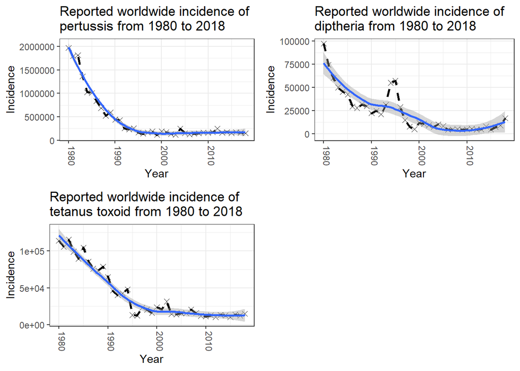

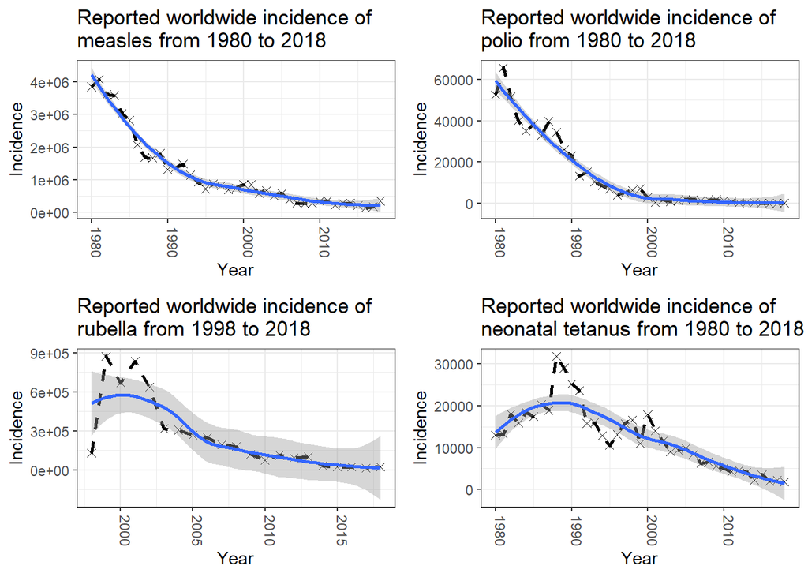

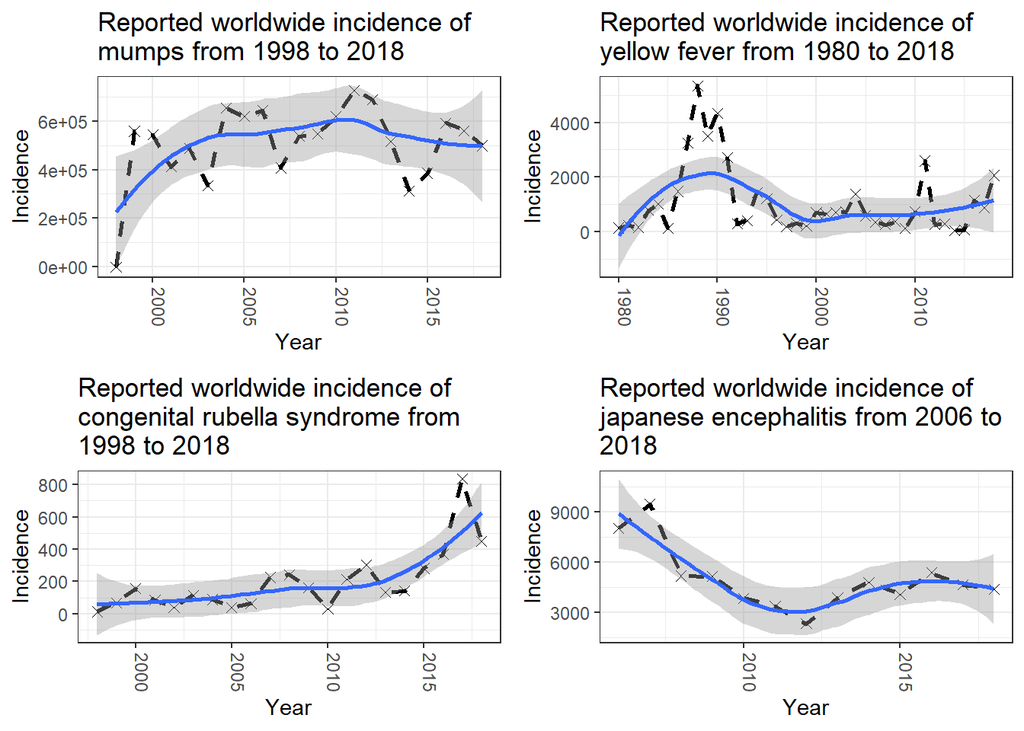

```r
# Generate plots

# Wrapper function for title fitting
wrapper <- function(x, ...)
{
  paste(strwrap(x, ...), collapse = "\n")
}

# Plots of reported worldwide incidence over time
  # CRS
crs <- ggplot(total_crs_incidence_by_year, aes(Year, Incidence)) +
  geom_line(size = 1, linetype = 2) +
  geom_point(shape = 4, size = 2) +
  scale_color_manual(values = c("black", "gray40")) +
  theme_bw() +
  geom_smooth() +
  ggtitle(wrapper(paste("Reported worldwide incidence of congenital rubella syndrome from ", min(years_crs), "to ", max(years_crs)), width = 35)) +
theme(plot.title = element_text(hjust = 0),
      axis.text.x = element_text(angle = -90, hjust = 0, vjust = 0))

  # Diptheria
dip <- ggplot(total_dip_incidence_by_year, aes(Year, Incidence)) +
  geom_line(size = 1, linetype = 2) +
  geom_point(shape = 4, size = 2) +
  scale_color_manual(values = c("black", "gray40")) +
  theme_bw() +
  geom_smooth() +
  ggtitle(wrapper(paste("Reported worldwide incidence of diptheria from ", min(years_dip), "to ", max(years_dip)), width = 35)) +
theme(plot.title = element_text(hjust = 0),
      axis.text.x = element_text(angle = -90, hjust = 0, vjust = 0))

  # Japanese Encephalitis
jap <- ggplot(total_japenc_incidence_by_year, aes(Year, Incidence)) +
  geom_line(size = 1, linetype = 2) +
  geom_point(shape = 4, size = 2) +
  scale_color_manual(values = c("black", "gray40")) +
  theme_bw() +
  geom_smooth() +
  ggtitle(wrapper(paste("Reported worldwide incidence of japanese encephalitis from ", min(years_japenc), "to ", max(years_japenc)), width = 35)) +
theme(plot.title = element_text(hjust = 0),
      axis.text.x = element_text(angle = -90, hjust = 0, vjust = 0))

  # Measles
mea <- ggplot(total_measles_incidence_by_year, aes(Year, Incidence)) +
  geom_line(size = 1, linetype = 2) +
  geom_point(shape = 4, size = 2) +
  scale_color_manual(values = c("black", "gray40")) +
  theme_bw() +
  geom_smooth() +
  ggtitle(wrapper(paste("Reported worldwide incidence of measles from ", min(years_measles), "to ", max(years_measles)), width = 35)) +
theme(plot.title = element_text(hjust = 0),
      axis.text.x = element_text(angle = -90, hjust = 0, vjust = 0))

  # Mumps
mum <- ggplot(total_mumps_incidence_by_year, aes(Year, Incidence)) +
  geom_line(size = 1, linetype = 2) +
  geom_point(shape = 4, size = 2) +
  scale_color_manual(values = c("black", "gray40")) +
  theme_bw() +
  geom_smooth() +
  ggtitle(wrapper(paste("Reported worldwide incidence of mumps from ", min(years_mumps), "to ", max(years_mumps)), width = 35)) +
theme(plot.title = element_text(hjust = 0),
      axis.text.x = element_text(angle = -90, hjust = 0, vjust = 0))

  # Neonatal Tetanus
neo <- ggplot(total_ntet_incidence_by_year, aes(Year, Incidence)) +
  geom_line(size = 1, linetype = 2) +
  geom_point(shape = 4, size = 2) +
  scale_color_manual(values = c("black", "gray40")) +
  theme_bw() +
  geom_smooth() +
  ggtitle(wrapper(paste("Reported worldwide incidence of neonatal tetanus from ", min(years_ntet), "to ", max(years_ntet)), width = 35)) +
theme(plot.title = element_text(hjust = 0),
      axis.text.x = element_text(angle = -90, hjust = 0, vjust = 0))

  # Pertussis
per <- ggplot(total_pertussis_incidence_by_year, aes(Year, Incidence)) +
  geom_line(size = 1, linetype = 2) +
  geom_point(shape = 4, size = 2) +
  scale_color_manual(values = c("black", "gray40")) +
  theme_bw() +
  geom_smooth() +
  ggtitle(wrapper(paste("Reported worldwide incidence of pertussis from ", min(years_pertussis), "to ", max(years_pertussis)), width = 35)) +
theme(plot.title = element_text(hjust = 0),
      axis.text.x = element_text(angle = -90, hjust = 0, vjust = 0))

  # Polio
pol <- ggplot(total_polio_incidence_by_year, aes(Year, Incidence)) +
  geom_line(size = 1, linetype = 2) +
  geom_point(shape = 4, size = 2) +
  scale_color_manual(values = c("black", "gray40")) +
  theme_bw() +
  geom_smooth() +
  ggtitle(wrapper(paste("Reported worldwide incidence of polio from ", min(years_polio), "to ", max(years_polio)), width = 35)) +
theme(plot.title = element_text(hjust = 0),
      axis.text.x = element_text(angle = -90, hjust = 0, vjust = 0))

  # Rubella
rub <- ggplot(total_rubella_incidence_by_year, aes(Year, Incidence)) +
  geom_line(size = 1, linetype = 2) +
  geom_point(shape = 4, size = 2) +
  scale_color_manual(values = c("black", "gray40")) +
  theme_bw() +
  geom_smooth() +
  ggtitle(wrapper(paste("Reported worldwide incidence of rubella from ", min(years_rubella), "to ", max(years_rubella)), width = 35)) +
theme(plot.title = element_text(hjust = 0),
      axis.text.x = element_text(angle = -90, hjust = 0, vjust = 0))

  # TTetanus
tte <- ggplot(total_ttet_incidence_by_year, aes(Year, Incidence)) +
  geom_line(size = 1, linetype = 2) +
  geom_point(shape = 4, size = 2) +
  scale_color_manual(values = c("black", "gray40")) +
  theme_bw() +
  geom_smooth() +
  ggtitle(wrapper(paste("Reported worldwide incidence of tetanus toxoid from ", min(years_ttet), "to ", max(years_ttet)), width = 35)) +
theme(plot.title = element_text(hjust = 0),
      axis.text.x = element_text(angle = -90, hjust = 0, vjust = 0))

  # Yellow Fever
yel <- ggplot(total_yfever_incidence_by_year, aes(Year, Incidence)) +
  geom_line(size = 1, linetype = 2) +
  geom_point(shape = 4, size = 2) +
  scale_color_manual(values = c("black", "gray40")) +
  theme_bw() +
  geom_smooth() +
  ggtitle(wrapper(paste("Reported worldwide incidence of yellow fever from ", min(years_yfever), "to ", max(years_yfever)), width = 35)) +
theme(plot.title = element_text(hjust = 0),
      axis.text.x = element_text(angle = -90, hjust = 0, vjust = 0))

figure1 <- ggarrange(per, dip, tte
                    # labels = c("A", "B", "C"),
                    # ncol = 1, nrow = 3
                    )

figure2 <- ggarrange(mea, pol, rub, neo
                    # labels = c("A", "B", "C"),
                    # ncol = 1, nrow = 3
                    )

figure3 <- ggarrange(mum, yel, crs, jap
                    # labels = c("A", "B", "C"),
                    # ncol = 1, nrow = 3
                    )

figure1; figure2; figure3;
```

For these line plots, I used smoothing to highlight overarching trends in reported cases. We can see clearly for the most part that reported worldwide incidence of each of the diseases included in this analysis has greatly decreased from the 1980s to present day. Examples include pertussis, tetanus toxoid, measles, and polio. Note, this trend is not as clear for mumps, congenital rubella syndrome, or yellow fever. In fact, the trend for congenital rubella syndrome is a net increase since reporting started, though this may be an artifact of inaccurate reporting.

We picked a handful of infectious diseases to take a particular look at (diphtheria, pertussis, measles, polio, and rubella), and looked at the number of countries that achieved the immunity threshold as defined by coverage of particular vaccines over time. The vaccines we chose for analysis are DTP3 for diphtheria and pertussis coverage, MCV1 for measles coverage, Pol3 for polio coverage, and RCV1 for rubella coverage. The number in the vaccine name refers to which dose of the vaccine it is (since vaccines are typically given over several doses for greatest efficacy), and we chose these to simply to maximize the data we had to work with. These diseases were also good to look at because they are more commonly known and as a result may be better reported.

```r
# Focus on coverage of DTP3 (for diphtheria, tetanus, and pertussis)
# DTP1_coverage <- filter(coverage_series, Vaccine == "DTP1")
DTP3_coverage <- filter(coverage_series, Vaccine == "DTP3")

# Focus on coverage of MCV1 (for measles)
MCV1_coverage <- filter(coverage_series, Vaccine == "MCV1")
# MCV2_coverage <- filter(coverage_series, Vaccine == "MCV2")

# Focus on coverage of Pol3 (for polio)
Pol3_coverage <- filter(coverage_series, Vaccine == "Pol3")

# Focus on coverage of RCV1 (for rubella)
RCV1_coverage <- filter(coverage_series, Vaccine == "RCV1")
```

We can perform some reorganization of the data to get the sum of countries that are at threshold.

```r
# Number of countries (out of 194 total) that are at or above the immunity threshold percentage

# Diphtheria
counts_dip <- list()
start_year <- min(DTP3_coverage$Year)
i <- 1
while (start_year != 2019) {
  cur_year_counts <- filter(DTP3_coverage, Year == start_year)
  coverages <- na.omit(cur_year_counts$Percent_coverage)
  coverage_count <- 0
  for (coverage in coverages) {
    if (coverage >= diphtheria_threshold) {
      coverage_count <- coverage_count + 1
    }
  }
  counts_dip[[i]] <- coverage_count
  i <- i + 1
  start_year <- start_year + 1
}

# Pertussis
counts_per <- list()
start_year <- min(DTP3_coverage$Year)
i <- 1
while (start_year != 2019) {
  cur_year_counts <- filter(DTP3_coverage, Year == start_year)
  coverages <- na.omit(cur_year_counts$Percent_coverage)
  coverage_count <- 0
  for (coverage in coverages) {
    if (coverage >= pertussis_threshold) {
      coverage_count <- coverage_count + 1
    }
  }
  counts_per[[i]] <- coverage_count
  i <- i + 1
  start_year <- start_year + 1
}

# Measles
counts_mea <- list()
start_year <- min(MCV1_coverage$Year)
i <- 1
while (start_year != 2019) {
  cur_year_counts <- filter(MCV1_coverage, Year == start_year)
  coverages <- na.omit(cur_year_counts$Percent_coverage)
  coverage_count <- 0
  for (coverage in coverages) {
    if (coverage >= measles_threshold) {
      coverage_count <- coverage_count + 1
    }
  }
  counts_mea[[i]] <- coverage_count
  i <- i + 1
  start_year <- start_year + 1
}

# Polio
counts_pol <- list()
start_year <- min(Pol3_coverage$Year)
i <- 1
while (start_year != 2019) {
  cur_year_counts <- filter(Pol3_coverage, Year == start_year)
  coverages <- na.omit(cur_year_counts$Percent_coverage)
  coverage_count <- 0
  for (coverage in coverages) {
    if (coverage >= polio_threshold) {
      coverage_count <- coverage_count + 1
    }
  }
  counts_pol[[i]] <- coverage_count
  i <- i + 1
  start_year <- start_year + 1
}

# Rubella
counts_rub <- list()
start_year <- min(RCV1_coverage$Year)
i <- 1
while (start_year != 2019) {
  cur_year_counts <- filter(RCV1_coverage, Year == start_year)
  coverages <- na.omit(cur_year_counts$Percent_coverage)
  coverage_count <- 0
  for (coverage in coverages) {
    if (coverage >= rubella_threshold) {
      coverage_count <- coverage_count + 1
    }
  }
  counts_rub[[i]] <- coverage_count
  i <- i + 1
  start_year <- start_year + 1
}
```

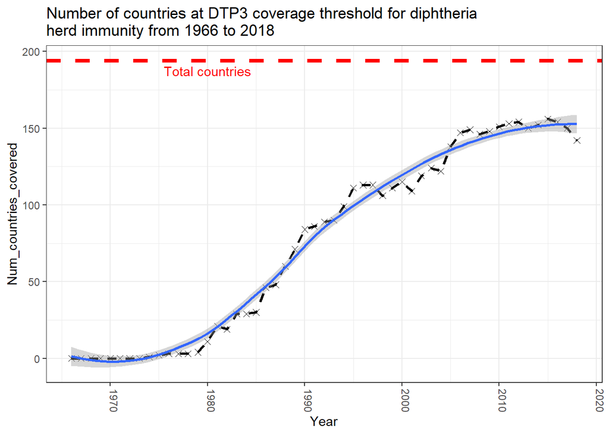

```r
# Number of countries that reach the vaccine coverage threshold for herd immunity for diphtheria over time
covered_thresh_dip <- data.frame(
  Year = min(DTP3_coverage$Year):2018,
  Num_countries_covered = unlist(counts_dip)
)

ggplot(covered_thresh_dip, aes(Year, Num_countries_covered)) +
  geom_line(size = 1, linetype = 2) +
  geom_point(shape = 4, size = 2) +
  geom_smooth() +
  scale_color_manual(values = c("black", "gray40")) +
  theme_bw() +
  ggtitle(wrapper(paste("Number of countries at DTP3 coverage threshold for diphtheria herd immunity from ", min(DTP3_coverage$Year), " to 2018"), width = 65)) +
theme(plot.title = element_text(hjust = 0),
      axis.text.x = element_text(angle = -90, hjust = 0, vjust = 0)) +
  geom_hline(yintercept = 194, linetype = "dashed", color = "red", size = 1.5) +
  geom_text(data=data.frame(x = 1980, y = 194), aes(x, y), label = "Total countries", color = "red", vjust = 1.5)
```

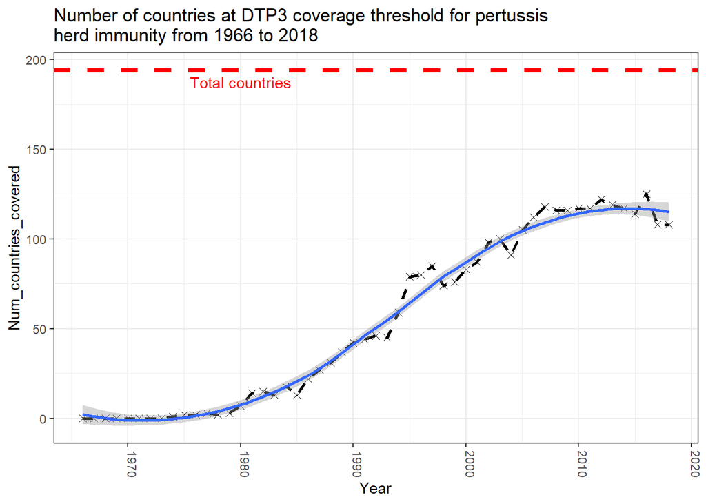

```r
# Number of countries that reach the vaccine coverage threshold for herd immunity for pertussis over time
covered_thresh_per <- data.frame(
  Year = min(DTP3_coverage$Year):2018,
  Num_countries_covered = unlist(counts_per)
)

ggplot(covered_thresh_per, aes(Year, Num_countries_covered)) +
  geom_line(size = 1, linetype = 2) +
  geom_point(shape = 4, size = 2) +
  geom_smooth() +
  scale_color_manual(values = c("black", "gray40")) +
  theme_bw() +
  ggtitle(wrapper(paste("Number of countries at DTP3 coverage threshold for pertussis herd immunity from ", min(DTP3_coverage$Year), " to 2018"), width = 65)) +
theme(plot.title = element_text(hjust = 0),
      axis.text.x = element_text(angle = -90, hjust = 0, vjust = 0)) +
  geom_hline(yintercept = 194, linetype = "dashed", color = "red", size = 1.5) +
  geom_text(data=data.frame(x = 1980, y = 194), aes(x, y), label = "Total countries", color = "red", vjust = 1.5)
```

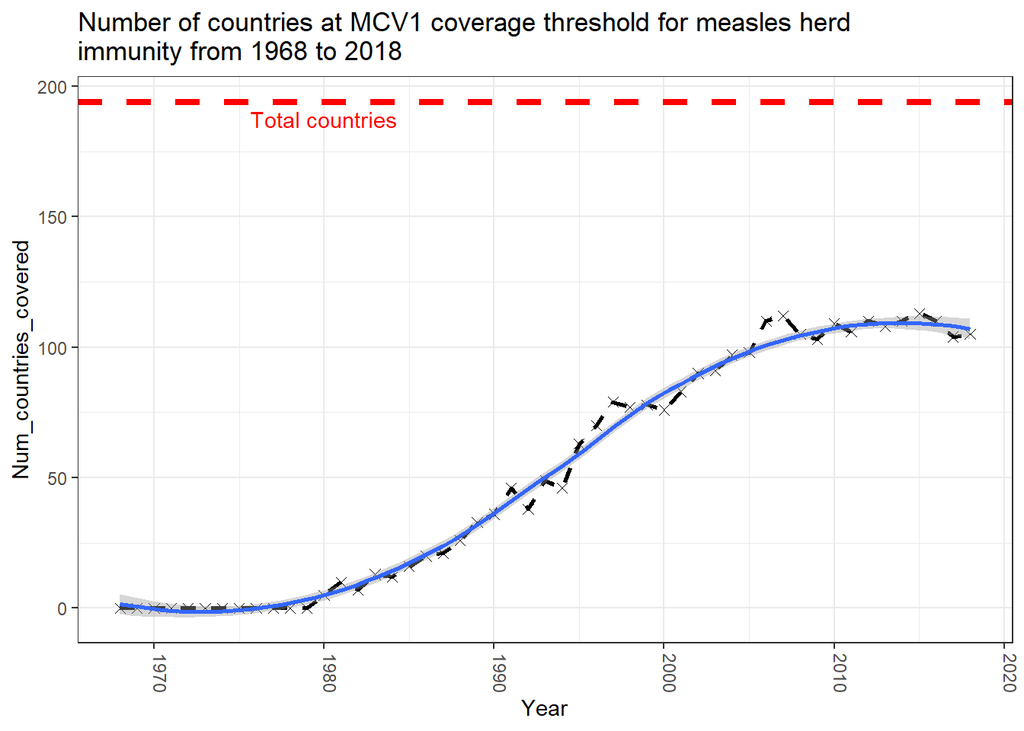

```r
# Number of countries that reach the vaccine coverage threshold for herd immunity for measles over time
covered_thresh_mea <- data.frame(
  Year = min(MCV1_coverage$Year):2018,
  Num_countries_covered = unlist(counts_mea)
)

ggplot(covered_thresh_mea, aes(Year, Num_countries_covered)) +
  geom_line(size = 1, linetype = 2) +
  geom_point(shape = 4, size = 2) +
  geom_smooth() +
  scale_color_manual(values = c("black", "gray40")) +
  theme_bw() +
  ggtitle(wrapper(paste("Number of countries at MCV1 coverage threshold for measles herd immunity from ", min(MCV1_coverage$Year), " to 2018"), width = 65)) +
theme(plot.title = element_text(hjust = 0),
      axis.text.x = element_text(angle = -90, hjust = 0, vjust = 0)) +
  geom_hline(yintercept = 194, linetype = "dashed", color = "red", size = 1.5) +
  geom_text(data=data.frame(x = 1980, y = 194), aes(x, y), label = "Total countries", color = "red", vjust = 1.5)
```

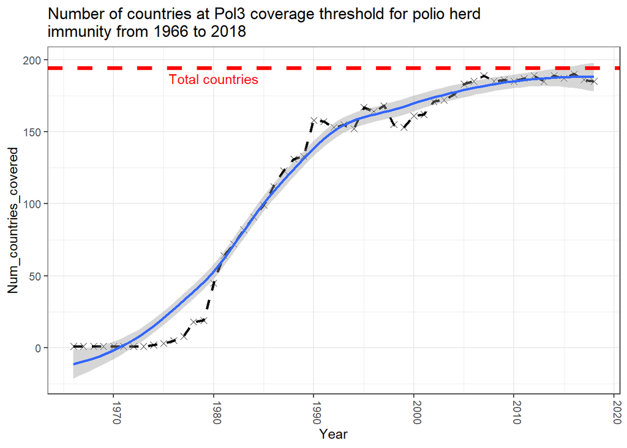

```r
# Number of countries that reach the vaccine coverage threshold for herd immunity for polio over time
covered_thresh_pol <- data.frame(
  Year = min(Pol3_coverage$Year):2018,
  Num_countries_covered = unlist(counts_pol)
)

ggplot(covered_thresh_pol, aes(Year, Num_countries_covered)) +
  geom_line(size = 1, linetype = 2) +
  geom_point(shape = 4, size = 2) +
  geom_smooth() +
  scale_color_manual(values = c("black", "gray40")) +
  theme_bw() +
  ggtitle(wrapper(paste("Number of countries at Pol3 coverage threshold for polio herd immunity from ", min(Pol3_coverage$Year), " to 2018"), width = 65)) +
theme(plot.title = element_text(hjust = 0),
      axis.text.x = element_text(angle = -90, hjust = 0, vjust = 0)) +
  geom_hline(yintercept = 194, linetype = "dashed", color = "red", size = 1.5) +
  geom_text(data=data.frame(x = 1980, y = 194), aes(x, y), label = "Total countries", color = "red", vjust = 1.5)
```

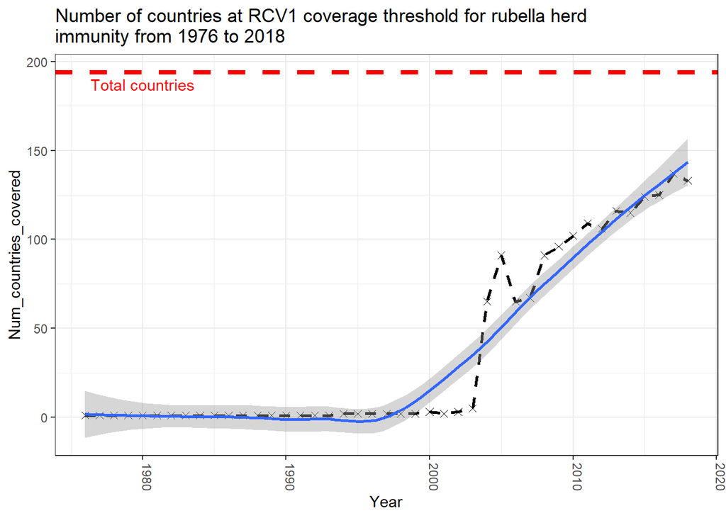

```r
# Number of countries that reach the vaccine coverage threshold for herd immunity for rubella over time
covered_thresh_rub <- data.frame(
  Year = min(RCV1_coverage$Year):2018,
  Num_countries_covered = unlist(counts_rub)
)

ggplot(covered_thresh_rub, aes(Year, Num_countries_covered)) +
  geom_line(size = 1, linetype = 2) +
  geom_point(shape = 4, size = 2) +
  geom_smooth() +
  scale_color_manual(values = c("black", "gray40")) +
  theme_bw() +
  ggtitle(wrapper(paste("Number of countries at RCV1 coverage threshold for rubella herd immunity from ", min(RCV1_coverage$Year), " to 2018"), width = 65)) +
theme(plot.title = element_text(hjust = 0),
      axis.text.x = element_text(angle = -90, hjust = 0, vjust = 0)) +
  geom_hline(yintercept = 194, linetype = "dashed", color = "red", size = 1.5) +
  geom_text(data=data.frame(x = 1980, y = 194), aes(x, y), label = "Total countries", color = "red", vjust = 1.5)
```

As expected, we see that worldwide coverage for each of these vaccines has increased dramatically across time. Particularly significant is polio, where almost every country in the world has achieved the immunity threshold. For the rest of these vaccines however, there is still a significant number of countries that are not at threshold, and where those diseases still persist. Furthermore, we see that recently (within the past 5 years) there as been a stagnation in coverage. Other than polio, there are at least 50 countries (~25%) that are not at the coverage necessary for herd immunity for each of the analyzed diseases.

### Results

Next, we use the regions defined by WHO to see incidence by year and by region to identify what areas are still observing high incidence and highlight the recent trends in the past 5 years regarding disease incidence. We also perform geospatial analysis to visually identify specific countries that either have a high number of reported cases or have not reached the threshold coverage specified in the above chart.

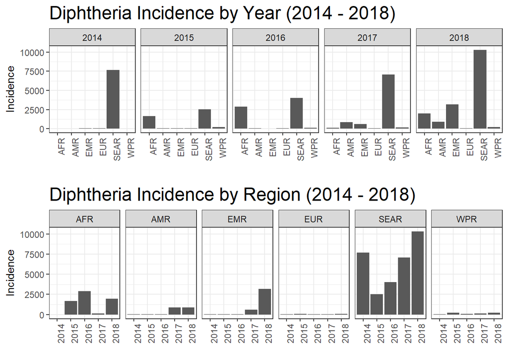

```r
# For ease of access
regional_global_incidence <- read.csv(url("https://raw.githubusercontent.com/davemai/BMIN503_Final_Project/master/data/regional_global_incidence.csv"), header = TRUE)

# Rename disease values in entries
regional_global_incidence$Disease <- revalue(regional_global_incidence$Disease, c("CRS" = "congenital rubella syndrome", "JapEnc" = "japanese encephalitis", "ntetanus" = "neonatal tetanus", "Mumps" = "mumps", "Rubella" = "rubella", "ttetanus" = "tetanus toxoid", "yfever" = "yellow fever"))
colnames(regional_global_incidence) <- str_remove(colnames(regional_global_incidence), "X")

# Take only 2014 - 2018 (recent years) for analysis
regional_global_incidence <- select(regional_global_incidence, "region", "Disease", "2014", "2015", "2016", "2017", "2018")

# Filter dataframes
regional_dip_incidence <- filter(regional_global_incidence, Disease == "diphtheria", region != "world")
regional_per_incidence <- filter(regional_global_incidence, Disease == "pertussis", region != "world")
regional_mea_incidence <- filter(regional_global_incidence, Disease == "measles", region != "world")
regional_pol_incidence <- filter(regional_global_incidence, Disease == "polio", region != "world")
regional_rub_incidence <- filter(regional_global_incidence, Disease == "rubella", region != "world")

# Reformat dataframe with 'melt'
regional_dip_incidence <- melt(regional_dip_incidence)
regional_per_incidence <- melt(regional_per_incidence)
regional_mea_incidence <- melt(regional_mea_incidence)
regional_pol_incidence <- melt(regional_pol_incidence)
regional_rub_incidence <- melt(regional_rub_incidence)

dip_by_year <- ggplot(regional_dip_incidence, aes(region, value)) +
  geom_bar(stat = "identity") +
  facet_wrap(~variable, ncol = 5) +
  theme_bw() +
  ylab("Incidence") +
  ggtitle("Diphtheria Incidence by Year (2014 - 2018)") +
  theme(plot.title = element_text(hjust = 0, size = 18)) +
  theme(axis.text.x = element_text(angle = 90, hjust = 1)) +
  scale_x_discrete(name = "")

dip_by_region <- ggplot(regional_dip_incidence, aes(variable, value)) +
  geom_bar(stat = "identity") +
  facet_wrap(~region, ncol = 6) +
  theme_bw() +
  ylab("Incidence") +
  ggtitle("Diphtheria Incidence by Region (2014 - 2018)") +
  theme(plot.title = element_text(hjust = 0, size = 18)) +
  theme(axis.text.x = element_text(angle = 90, hjust = 1)) +
  scale_x_discrete(name = "")

figure_dip <- ggarrange(dip_by_year, dip_by_region,
                    ncol = 1, nrow = 2)
figure_dip;
```

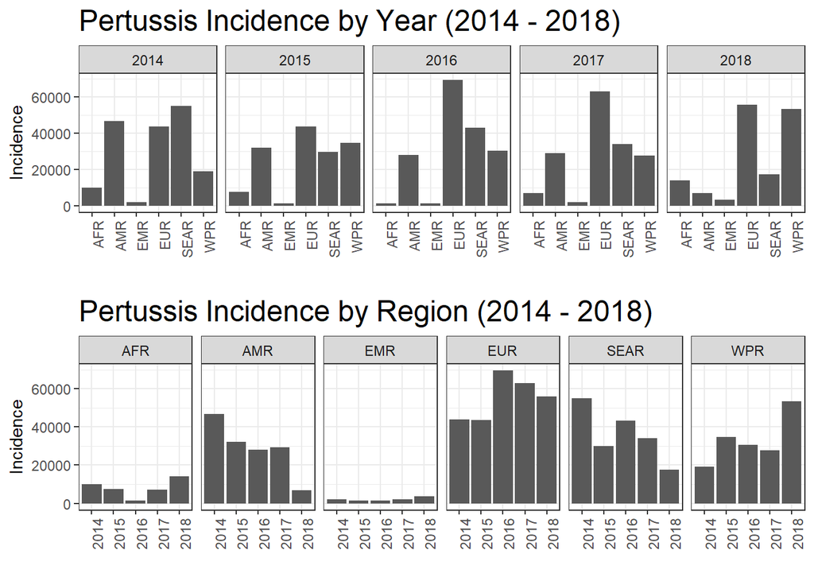

```r
per_by_year <- ggplot(regional_per_incidence, aes(region, value)) +
  geom_bar(stat = "identity") +
  facet_wrap(~variable, ncol = 5) +
  theme_bw() +
  ylab("Incidence") +
  ggtitle("Pertussis Incidence by Year (2014 - 2018)") +
  theme(plot.title = element_text(hjust = 0, size = 18)) +
  theme(axis.text.x = element_text(angle = 90, hjust = 1)) +
  scale_x_discrete(name = "")

per_by_region <- ggplot(regional_per_incidence, aes(variable, value)) +
  geom_bar(stat = "identity") +
  facet_wrap(~region, ncol = 6) +
  theme_bw() +
  ylab("Incidence") +
  ggtitle("Pertussis Incidence by Region (2014 - 2018)") +
  theme(plot.title = element_text(hjust = 0, size = 18)) +
  theme(axis.text.x = element_text(angle = 90, hjust = 1)) +
  scale_x_discrete(name = "")

figure_per <- ggarrange(per_by_year, per_by_region,
                    ncol = 1, nrow = 2)
figure_per;
```

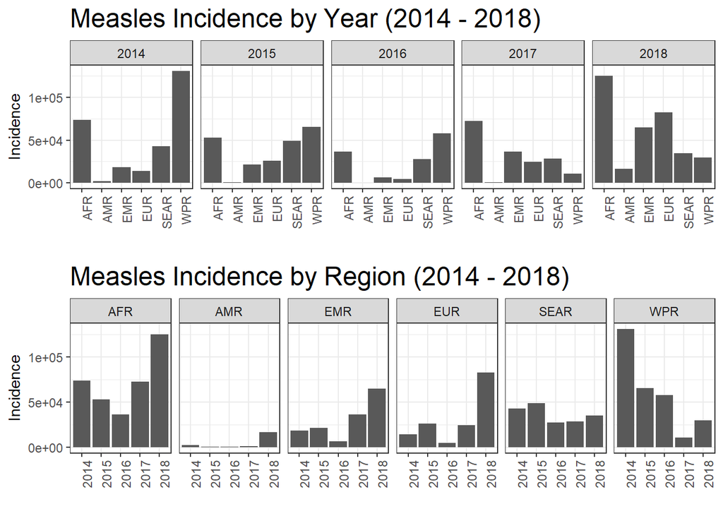

```r
mea_by_year <- ggplot(regional_mea_incidence, aes(region, value)) +
  geom_bar(stat = "identity") +
  facet_wrap(~variable, ncol = 5) +
  theme_bw() +
  ylab("Incidence") +
  ggtitle("Measles Incidence by Year (2014 - 2018)") +
  theme(plot.title = element_text(hjust = 0, size = 18)) +
  theme(axis.text.x = element_text(angle = 90, hjust = 1)) +
  scale_x_discrete(name = "")

mea_by_region <- ggplot(regional_mea_incidence, aes(variable, value)) +
  geom_bar(stat = "identity") +
  facet_wrap(~region, ncol = 6) +
  theme_bw() +
  ylab("Incidence") +
  ggtitle("Measles Incidence by Region (2014 - 2018)") +
  theme(plot.title = element_text(hjust = 0, size = 18)) +
  theme(axis.text.x = element_text(angle = 90, hjust = 1)) +
  scale_x_discrete(name = "")

figure_mea <- ggarrange(mea_by_year, mea_by_region,
                    ncol = 1, nrow = 2)
figure_mea;
```

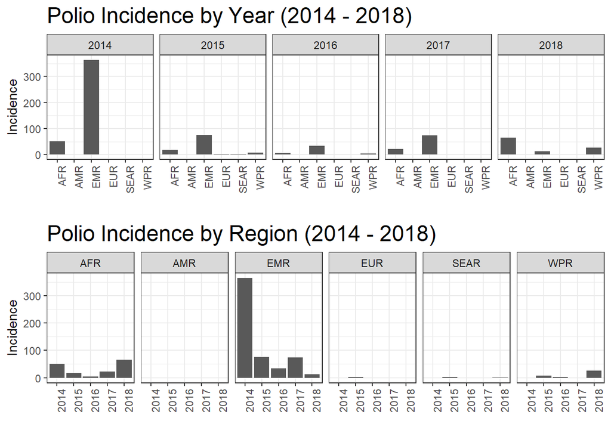

```r
pol_by_year <- ggplot(regional_pol_incidence, aes(region, value)) +
  geom_bar(stat = "identity") +
  facet_wrap(~variable, ncol = 5) +
  theme_bw() +
  ylab("Incidence") +
  ggtitle("Polio Incidence by Year (2014 - 2018)") +
  theme(plot.title = element_text(hjust = 0, size = 18)) +
  theme(axis.text.x = element_text(angle = 90, hjust = 1)) +
  scale_x_discrete(name = "")

pol_by_region <- ggplot(regional_pol_incidence, aes(variable, value)) +
  geom_bar(stat = "identity") +
  facet_wrap(~region, ncol = 6) +
  theme_bw() +
  ylab("Incidence") +
  ggtitle("Polio Incidence by Region (2014 - 2018)") +
  theme(plot.title = element_text(hjust = 0, size = 18)) +
  theme(axis.text.x = element_text(angle = 90, hjust = 1)) +
  scale_x_discrete(name = "")

figure_pol <- ggarrange(pol_by_year, pol_by_region,
                    ncol = 1, nrow = 2)
figure_pol;
```

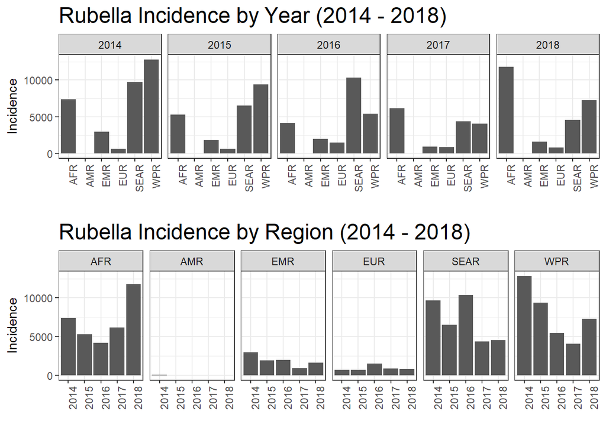

```r
rub_by_year <- ggplot(regional_rub_incidence, aes(region, value)) +
  geom_bar(stat = "identity") +
  facet_wrap(~variable, ncol = 5) +
  theme_bw() +
  ylab("Incidence") +
  ggtitle("Rubella Incidence by Year (2014 - 2018)") +
  theme(plot.title = element_text(hjust = 0, size = 18)) +
  theme(axis.text.x = element_text(angle = 90, hjust = 1)) +
  scale_x_discrete(name = "")

rub_by_region <- ggplot(regional_rub_incidence, aes(variable, value)) +
  geom_bar(stat = "identity") +
  facet_wrap(~region, ncol = 6) +
  theme_bw() +
  ylab("Incidence") +
  ggtitle("Rubella Incidence by Region (2014 - 2018)") +
  theme(plot.title = element_text(hjust = 0, size = 18)) +
  theme(axis.text.x = element_text(angle = 90, hjust = 1)) +
  scale_x_discrete(name = "")

figure_rub <- ggarrange(rub_by_year, rub_by_region,
                    ncol = 1, nrow = 2)
figure_rub;
```

We can also take a look at the recent vaccination trends for the particular vaccines that cover these pathogens. We plot the average vaccination coverage over the same past 5 years and for each of the WHO regions. Note that this averaging still obscures country-level information, as there may be particular countries that suffer significantly more in terms of achieving necessary vaccine coverage for herd immunity.

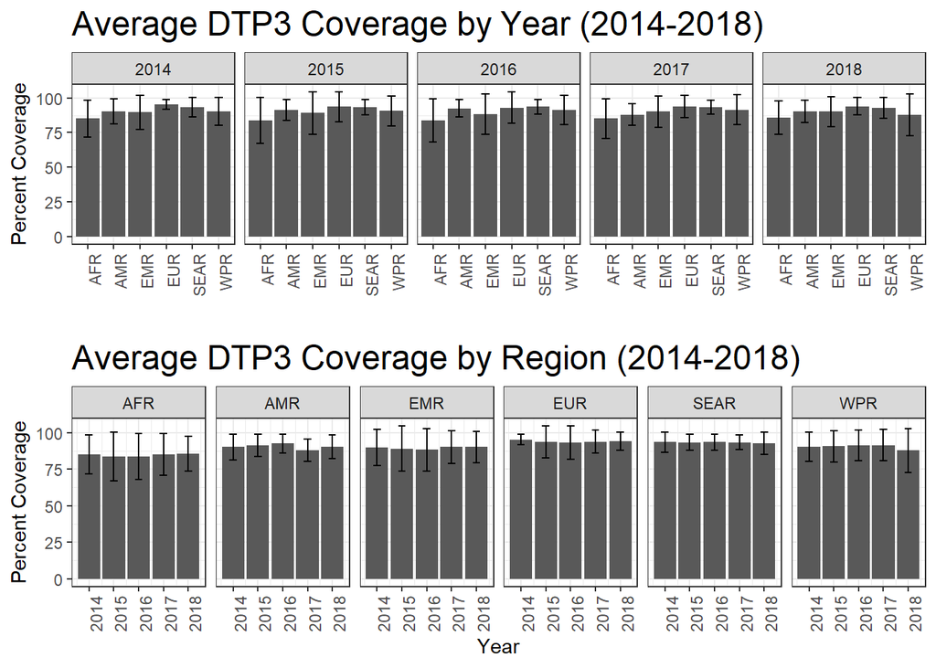

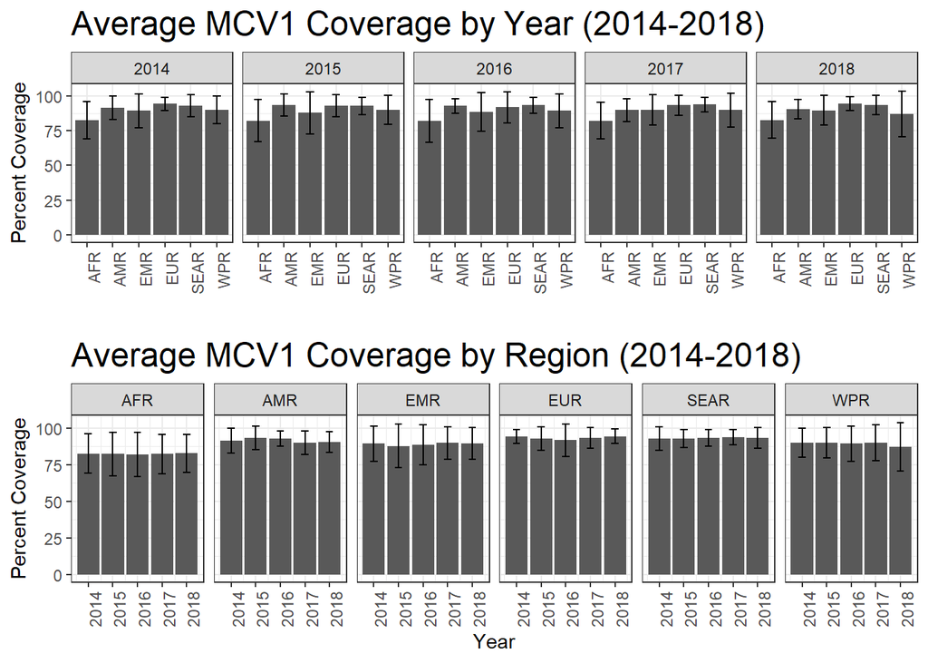

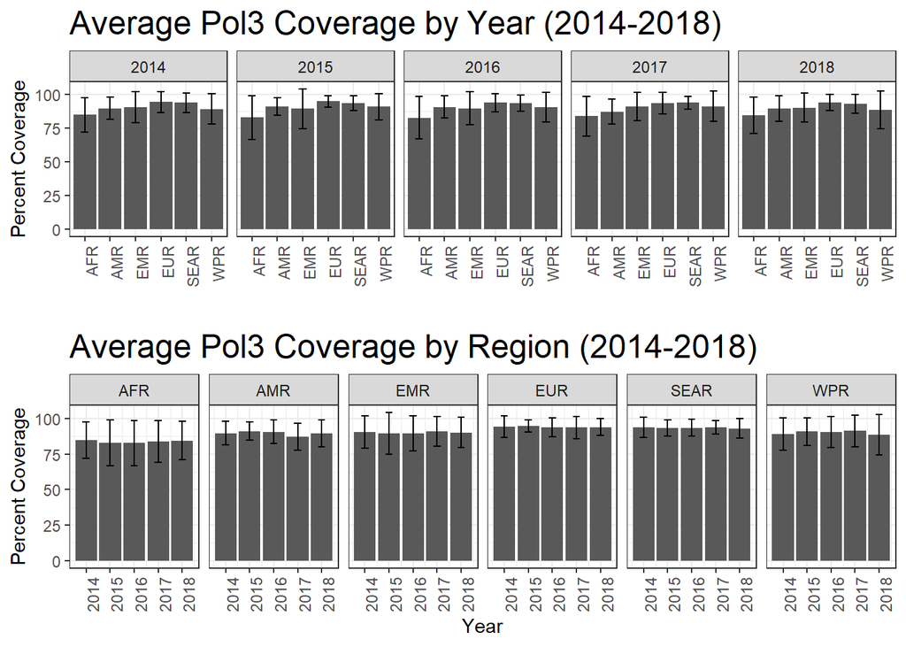

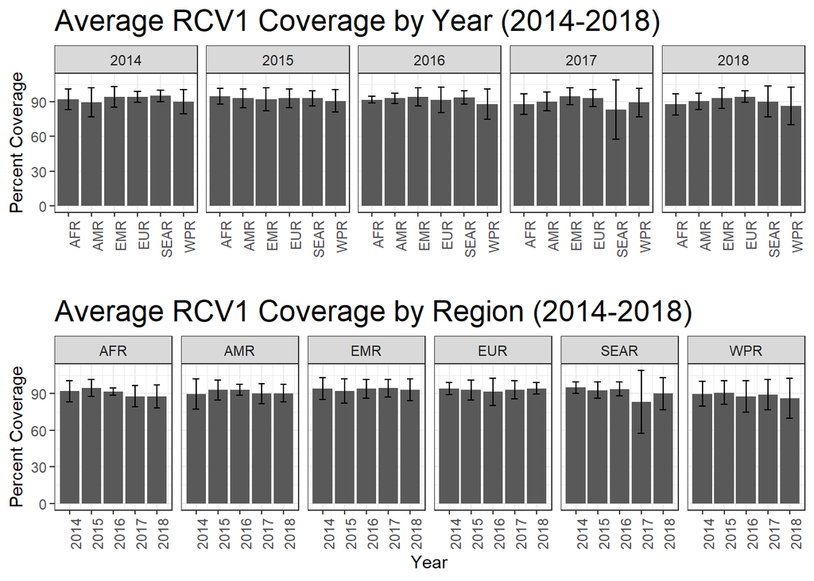

```r
# Filter dataframe to get only relevant information
recent_coverage <- coverage_series %>%
  filter(Year %in% c(2014, 2015, 2016, 2017, 2018)) %>%
  filter(Vaccine %in% c("DTP3", "MCV1", "Pol3", "RCV1"))

# Calculate average coverages and standard deviations per vaccine over region and year
averages <- list()
sds <- list()
iter <- 1
for (vac in unique(recent_coverage$Vaccine)) {
  for (region in levels(recent_coverage$WHO_REGION)) {
    for (year in unique(recent_coverage$Year)) {
      cur <- filter(recent_coverage, Vaccine == vac, WHO_REGION == region, Year == year)
      averages[[iter]] <- mean(cur$Percent_coverage, na.rm = TRUE)
      sds[[iter]] <- sd(cur$Percent_coverage, na.rm = TRUE)
      iter <- iter + 1
    }
  }
}

# Create dataframe for average coverages and the standard deviation per region over time
avg_coverages <- data.frame(
  WHO_REGION = rep(c(rep("AFR", 5), rep("AMR", 5), rep("EMR", 5), rep("EUR", 5), rep("SEAR", 5), rep("WPR", 5)), 4),
  Vaccine = c(rep("DTP3", 30), rep("MCV1", 30), rep("Pol3", 30), rep("RCV1", 30)),
  Year = rep(c(2014, 2015, 2016, 2017, 2018), 24),
  Avg_percent_coverage = unlist(averages),
  Std = unlist(sds)
)

by_year <- list()
iter <- 1
for (vac in unique(avg_coverages$Vaccine)) {
  cur <- ggplot(filter(avg_coverages, Vaccine == vac), aes(WHO_REGION, Avg_percent_coverage)) +
    geom_bar(stat = "identity") +
    geom_errorbar(aes(ymin = Avg_percent_coverage - Std, ymax = Avg_percent_coverage + Std), width = 0.3, position = position_dodge(.9)) +
    facet_wrap(~Year, ncol = 5) +
    theme_bw() +
    ylab("Percent Coverage") +
    ggtitle(paste("Average", vac,"Coverage by Year (2014-2018)")) +
    theme(plot.title = element_text(hjust = 0, size = 18)) +
    theme(axis.text.x = element_text(angle = 90, hjust = 1)) +
    scale_x_discrete(name = "")

  # Store plot in list
  by_year[[iter]] <- cur
  iter <- iter + 1
}

by_region <- list()
iter <- 1
for (vac in unique(avg_coverages$Vaccine)) {
  cur <- ggplot(filter(avg_coverages, Vaccine == vac), aes(Year, Avg_percent_coverage)) +
    geom_bar(stat = "identity") +
    geom_errorbar(aes(ymin = Avg_percent_coverage - Std, ymax = Avg_percent_coverage + Std), width = 0.3, position = position_dodge(.9)) +
    facet_wrap(~WHO_REGION, ncol = 6) +
    theme_bw() +
    ylab("Percent Coverage") +
    ggtitle(paste("Average", vac,"Coverage by Region (2014-2018)")) +
    theme(plot.title = element_text(hjust = 0, size = 18)) +
    theme(axis.text.x = element_text(angle = 90, hjust = 1))

  # Store plot in list
  by_region[[iter]] <- cur
  iter <- iter + 1
}

iter <- 1
while (iter < 5) {
  print(
    ggarrange(by_year[[iter]], by_region[[iter]],
                    ncol = 1, nrow = 2)
  )
  iter <- iter + 1
}
```

We take a closer look at 4 particular vaccines evaluated against protecting 5 diseases. We use DTP3 for diphtheria and pertussis coverage, MCV1 for measles coverage, Pol3 for polio coverage, and RCV1 for rubella coverage. The average coverage for DTP3 by year does not shift much, only fluctating up and down by several percent. Between regions we can see some differences in coverage up to around 10%, but for the most part coverage is fairly similar across the board. If we look at the coverage grouped by region, it’s evident that only several percent changes in coverage occur between years for all the regions. For this macroscopic analysis, this trend is similar for each of the vaccines we take a look at here. The most variability can be observed with RCV1 coverage, whereby AFR, SEAR, and WPR tend to fluctate more than for other vaccines, especially betwen 2016 and 2017.

Now that we have a sense of which regions are more prone to those particular diseases in terms of both reported cases and vaccination coverage, we can try to visualize them geospatially. Particularly, we can visualize incidence by country as well as which countries are or aren’t at the immunity threshold for each of our specified diseases from 2014 - 2018.

```r
# Add column to indicate whether a country is at threshold coverage for each year
DTP3_coverage$Covered_dip <- ifelse(DTP3_coverage$Percent_coverage >= diphtheria_threshold, "Yes", "No")
DTP3_coverage$Covered_per <- ifelse(DTP3_coverage$Percent_coverage >= pertussis_threshold, "Yes", "No")
MCV1_coverage$Covered <- ifelse(MCV1_coverage$Percent_coverage >= measles_threshold, "Yes", "No")
Pol3_coverage$Covered <- ifelse(Pol3_coverage$Percent_coverage >= polio_threshold, "Yes", "No")

# Show which countries are at threshold coverage from 2014 - 2018
data("World")
colnames(World)[which(names(World) == "iso_a3")] <- "ISO_code"

# Join datasets
world_coverage_dip_per <- inner_join(World, DTP3_coverage, "ISO_code")
world_coverage_measles <- inner_join(World, MCV1_coverage, "ISO_code")
world_coverage_polio <- inner_join(World, Pol3_coverage, "ISO_code")
```

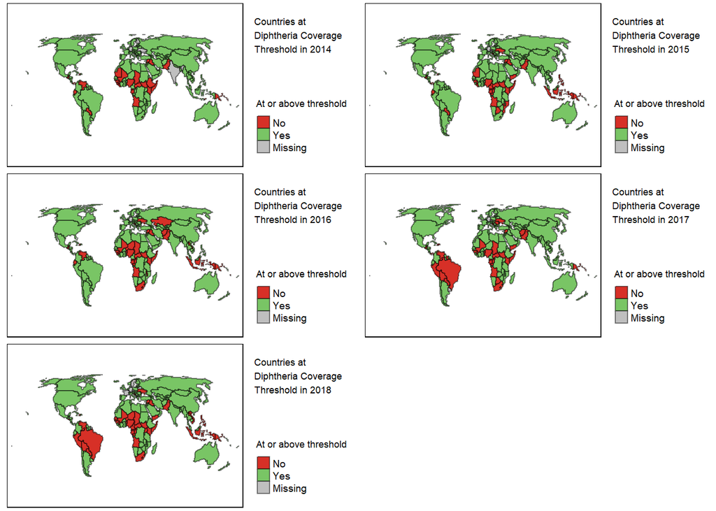

```r
# Plots: 2014 - 2018 for each disease
years <- c(2014, 2015, 2016, 2017, 2018)

  # Diphtheria
dip_figures <- list()
i <- 1
for (year in years) {
  fig <- tm_shape(filter(world_coverage_dip_per, Year == year)) +
  tm_polygons("Covered_dip", title = "At or above threshold",
    # showNA = TRUE,
    border.col = "black", border.alpha = .5,
    style = "cont",
    # breaks = c(0, 1),
    palette = "RdYlGn") +
  tm_layout(paste("Countries at\nDiphtheria Coverage\nThreshold in", year),
            legend.title.size = 1,
            legend.text.size = 0.6,
            legend.position = c("left","bottom"),
            legend.bg.color = "white",
            legend.bg.alpha = 1,
            legend.outside = TRUE)

  dip_figures[[i]] <- fig
  i <- i + 1
}
dip_coverage <- tmap_arrange(dip_figures[[1]], dip_figures[[2]], dip_figures[[3]], dip_figures[[4]], dip_figures[[5]])
dip_coverage;
```

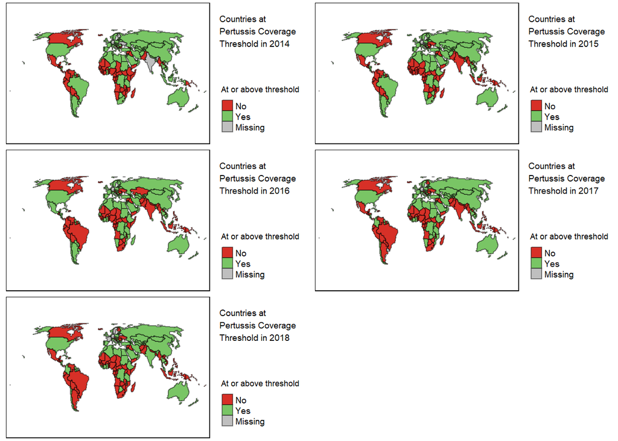

```r
  # Pertussis
per_figures <- list()
i <- 1
for (year in years) {
  fig <- tm_shape(filter(world_coverage_dip_per, Year == year)) +
  tm_polygons("Covered_per", title = "At or above threshold",
    # showNA = TRUE,
    border.col = "black", border.alpha = .5,
    style = "cont",
    # breaks = c(0, 1),
    palette = "RdYlGn") +
  tm_layout(paste("Countries at\nPertussis Coverage\nThreshold in", year),
            legend.title.size = 1,
            legend.text.size = 0.6,
            legend.position = c("left","bottom"),
            legend.bg.color = "white",
            legend.bg.alpha = 1,
            legend.outside = TRUE)

  per_figures[[i]] <- fig
  i <- i + 1
}
per_coverage <- tmap_arrange(per_figures[[1]], per_figures[[2]], per_figures[[3]], per_figures[[4]], per_figures[[5]])
per_coverage;
```

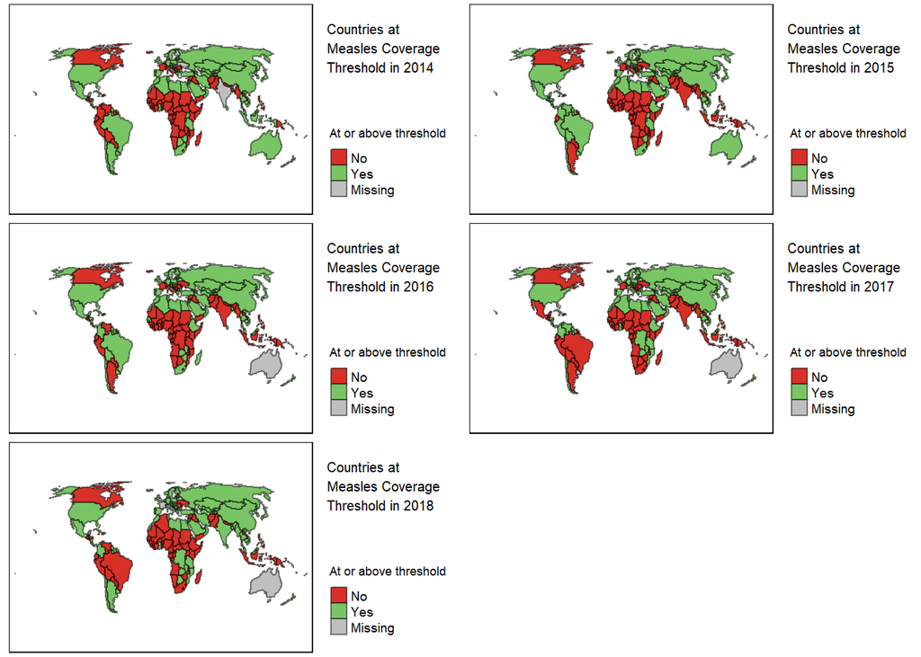

```r
  # Measles
mea_figures <- list()
i <- 1
for (year in years) {
  fig <- tm_shape(filter(world_coverage_measles, Year == year)) +
  tm_polygons("Covered", title = "At or above threshold",
    # showNA = TRUE,
    border.col = "black", border.alpha = .5,
    style = "cont",
    # breaks = c(0, 1),
    palette = "RdYlGn") +
  tm_layout(paste("Countries at\nMeasles Coverage\nThreshold in", year),
            legend.title.size = 1,
            legend.text.size = 0.6,
            legend.position = c("left","bottom"),
            legend.bg.color = "white",
            legend.bg.alpha = 1,
            legend.outside = TRUE)

  mea_figures[[i]] <- fig
  i <- i + 1
}
mea_coverage <- tmap_arrange(mea_figures[[1]], mea_figures[[2]], mea_figures[[3]], mea_figures[[4]], mea_figures[[5]])
mea_coverage;
```

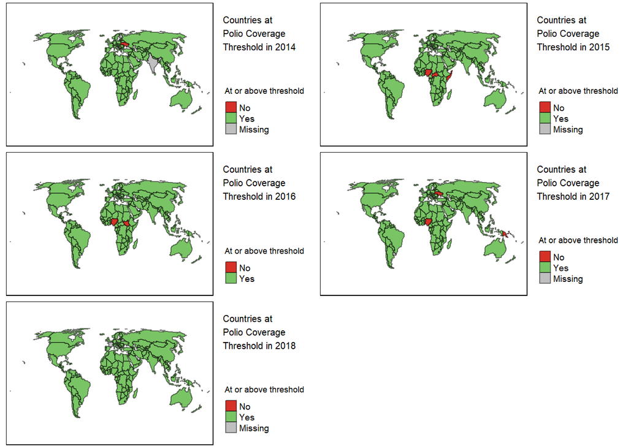

```r
  # Polio
pol_figures <- list()
i <- 1
for (year in years) {
  fig <- tm_shape(filter(world_coverage_polio, Year == year)) +
  tm_polygons("Covered", title = "At or above threshold",
    # showNA = TRUE,
    border.col = "black", border.alpha = .5,
    style = "cont",
    # breaks = c(0, 1),
    palette = "RdYlGn") +
  tm_layout(paste("Countries at\nPolio Coverage\nThreshold in", year),
            legend.title.size = 1,
            legend.text.size = 0.6,
            legend.position = c("left","bottom"),
            legend.bg.color = "white",
            legend.bg.alpha = 1,
            legend.outside = TRUE)

  pol_figures[[i]] <- fig
  i <- i + 1
}
pol_coverage <- tmap_arrange(pol_figures[[1]], pol_figures[[2]], pol_figures[[3]], pol_figures[[4]], pol_figures[[5]])
pol_coverage;
```

As expected, worldwide incidence of each of these infectious diseases have declined to stably low levels as vaccination coverage has increased and maintained a steadily high coverage rate. However, upon taking a closer look at specific countries, we see that there are actually ones that have seen an increased incidence, owing to a coverage rate that may not be sufficiently high. For diphtheria, we see that fewer countries are at threshold coverage in 2018 than in 2014, mainly within central Africa and parts of the EMR and SEAR regions. However, we also see that South America (Brazil) has fallen in coverage in the past two years. Pertussis coverage follows a similar trend, with parts of central/west and south Africa, the Americas, and Southeast Asia lacking coverage. More recently many South American countries have dipped in coverage, leading to much of the region being at sub-threshold by 2018 compared to 2014. Measles coverage is an alarming issue in much of Africa, with only shifting regions of coverage between 2014 - 2018. A similar number of countries seem to be covered, except South America again observed decreases in coverage leading to sub-threshold level coverages. Polio coverage is the most consistent between 2014 - 2018, with only several countries at sub-threshold level in parts of Africa and Europe. Note that the threshold for coverage for polio was designated to be 50% and is quite low (easy to achieve).

Now we move on to geospatial analysis of reported cases.

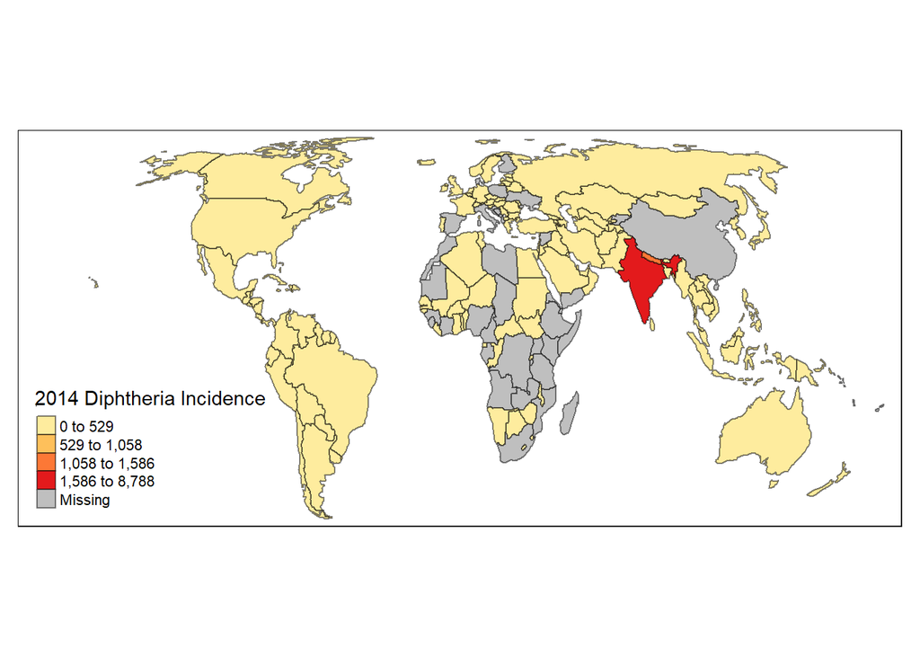

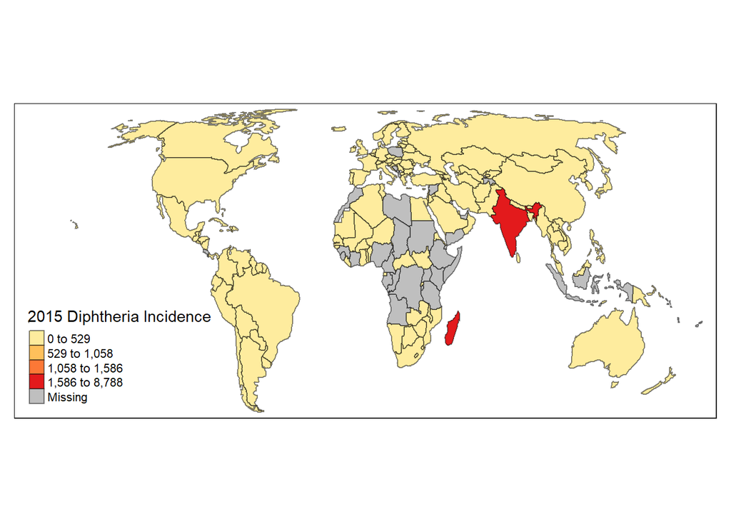

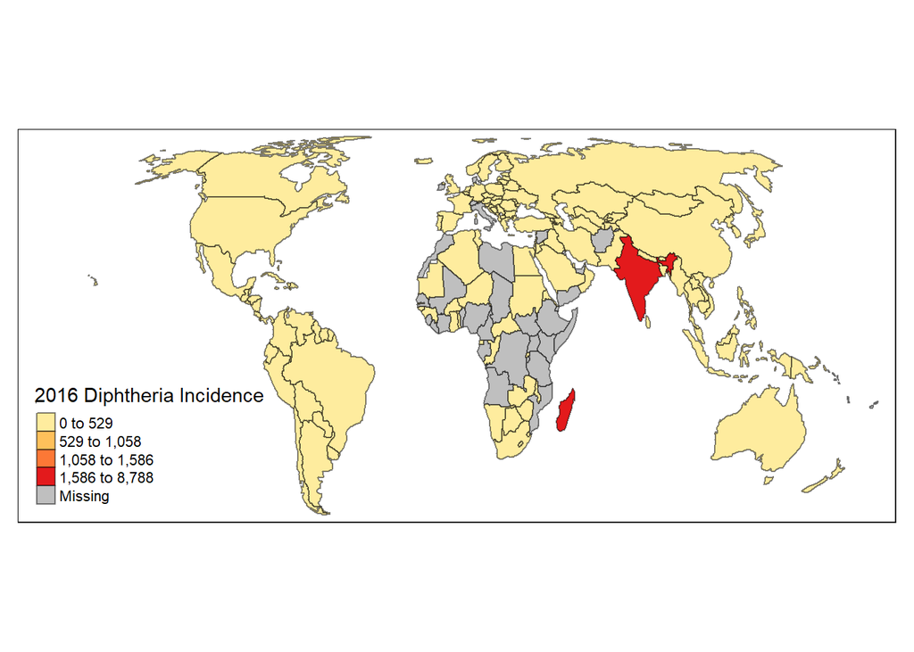

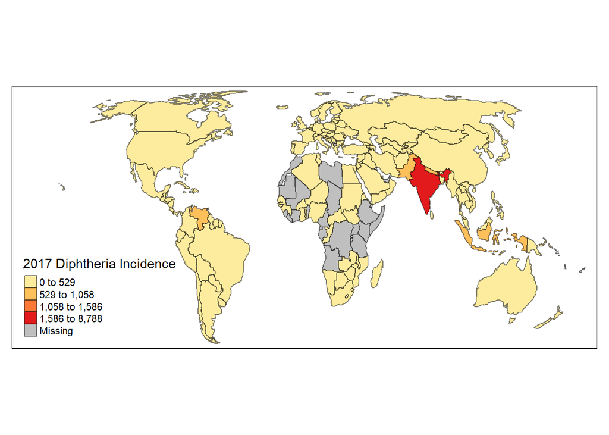

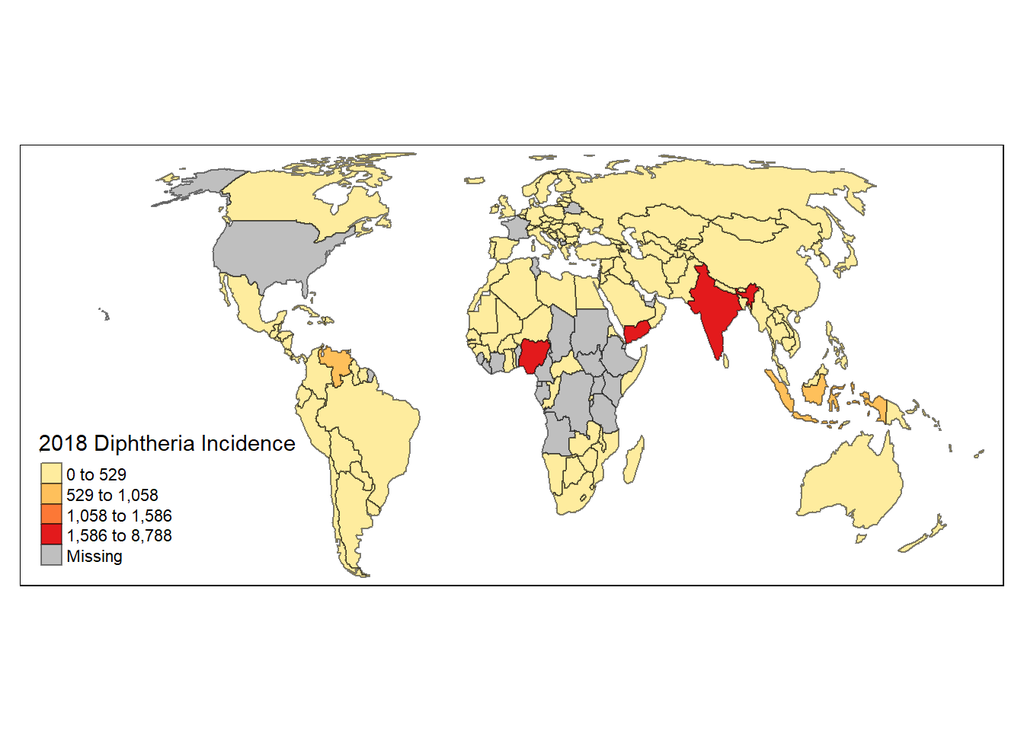

```r
# Geographical analysis of recent incidence (diphtheria, pertussis, polio, measles, rubella) by country (2014 - 2018)

data("World")
colnames(World)[which(names(World) == "iso_a3")] <- "ISO_code"

# Join datasets
world_incidence_diphtheria <- inner_join(World, diptheria_incidence, "ISO_code")
world_incidence_pertussis <- inner_join(World, pertussis_incidence, "ISO_code")
world_incidence_polio <- inner_join(World, polio_incidence, "ISO_code")
world_incidence_measles <- inner_join(World, measles_incidence, "ISO_code")
world_incidence_rubella <- inner_join(World, rubella_incidence, "ISO_code")
# Diphtheria
max_incidence <- max(max(na.omit(world_incidence_diphtheria$X2014)), max(na.omit(world_incidence_diphtheria$X2015)), max(na.omit(world_incidence_diphtheria$X2016)), max(na.omit(world_incidence_diphtheria$X2017)), max(na.omit(world_incidence_diphtheria$X2018)))

mean_incidence <- mean(mean(na.omit(world_incidence_diphtheria$X2014)), mean(na.omit(world_incidence_diphtheria$X2015)), mean(na.omit(world_incidence_diphtheria$X2016)), mean(na.omit(world_incidence_diphtheria$X2017)), mean(na.omit(world_incidence_diphtheria$X2018)))

sd_incidence <- sd(c(na.omit(world_incidence_diphtheria$X2014), na.omit(world_incidence_diphtheria$X2015), na.omit(world_incidence_diphtheria$X2016), na.omit(world_incidence_diphtheria$X2017), na.omit(world_incidence_diphtheria$X2018)))

for (year in c("X2014", "X2015", "X2016", "X2017", "X2018")) {
  print(
    tm_shape(world_incidence_diphtheria) +
    tm_polygons(year, title = paste(str_remove(year, "X"), "Diphtheria Incidence"),
              # showNA = FALSE,
              border.col = "black", border.alpha = .5,
              style = "fixed",
              breaks = c(0, sd_incidence, 2*sd_incidence, 3*sd_incidence, max_incidence),
              palette = "YlOrRd")
  )
}
```

```r
# Pertussis
max_incidence <- max(max(na.omit(world_incidence_pertussis$X2014)), max(na.omit(world_incidence_pertussis$X2015)), max(na.omit(world_incidence_pertussis$X2016)), max(na.omit(world_incidence_pertussis$X2017)), max(na.omit(world_incidence_pertussis$X2018)))

mean_incidence <- mean(mean(na.omit(world_incidence_pertussis$X2014)), mean(na.omit(world_incidence_pertussis$X2015)), mean(na.omit(world_incidence_pertussis$X2016)), mean(na.omit(world_incidence_pertussis$X2017)), mean(na.omit(world_incidence_pertussis$X2018)))

sd_incidence <- sd(c(na.omit(world_incidence_pertussis$X2014), na.omit(world_incidence_pertussis$X2015), na.omit(world_incidence_pertussis$X2016), na.omit(world_incidence_pertussis$X2017), na.omit(world_incidence_pertussis$X2018)))

for (year in c("X2014", "X2015", "X2016", "X2017", "X2018")) {
  print(
    tm_shape(world_incidence_pertussis) +
    tm_polygons(year, title = paste(str_remove(year, "X"), "Pertussis Incidence"),
              # showNA = FALSE,
              border.col = "black", border.alpha = .5,
              style = "fixed",
              breaks = c(0, sd_incidence, 2*sd_incidence, 3*sd_incidence, max_incidence),
              palette = "YlOrRd")
  )
}
```

[figure not shown]

[figure not shown]

[figure not shown]

[figure not shown]

[figure not shown]